# PWS Pink Salmon Run Timing

Ocean Entry vs. Aerial Survey

Kyle Shedd

2026-10-27;last opened: 2026-10-29

# Objective

The objective of this R Notebook is to provide average run tiiming curves for PWS pink salmon to see how it correlates to *lrrc9* haplotypes. We’ll be using the ocean sampling data from the AHRP 2013-2015 reported in [Knudsen et al. 2021](https://doi.org/10.1002/mcf2.10134) and average peak aerial survey stream counts for stream collections (data provided by Jenni Morella, PWS Research AMB). This is different from the previous `run_timing.Rmd`, which focused on collection-specific run timing to see where our WGR samples fit in against their run timing (i.e., did they sample the early, mid, or late run for a given stock?). Ultimately I will provide them all three sources of data:

1. previous collection-specific data from `run_timing.Rmd`,
2. escapement run timing from aerial survyes, both by district and across PWS for each lineage, and
3. ocean test fishing data from PWS entrances 2013-2015

# Background

Will Hemstrom and Mark Christie at Purdue University have found a large-effect locus (*lrrc9*) for hatchery x hatchery and hatchery x natural comparisons, but not in natural x natural comparisons. Independently, and beforehand, Wes Larson and Pat Barry found strong evidence that *lrrc9* is tied to run timing in Auke Creek pink salmon. Based on their work and the pairwise Fst outlier data from Will (most of which involve VFDA hatchery, known early run timing), we have strong reason to believe that this region of the genome is associated with run timing.

# Setup

Load all necessary packages, as of 2023-08-11 Kyle switched to GCLr.

```r
rm(list = ls(all.names = TRUE))

if(!require("pacman")) install.packages("pacman"); library(pacman)

pacman::p_load(
  tidyverse,
  lubridate,
  scales,
  janitor,
  GCLr,
  slider
)

knitr::opts_chunk$set(fig.width = 10)

# source("~/R/Functions.GCL.R")  # source GCL scripts, switched to GCLr package
.username = readLines("~/R/usr_pw.txt", n = 1)  # LOKI username
.password = readLines("~/R/usr_pw.txt" , n = 2)[[2]]  # LOKI password
```

# Import Data

## Ocean Sampling

This data came from the AHRP (aka HWI) ocean survey data from 2013-2015, which is available from the department [website](https://mtalab.adfg.alaska.gov/Hatchery_Wild_Interaction/HWIReports.aspx) with login credentials.

```r
(
  ocean <-
    readr::read_lines(file = "../data/run_timing/Ocean Report-560.csv", skip = 11) |>
    stringr::str_replace_all('5 1/8" panel', '5 1/8"" panel') |>  # quotation marks are not escaped...
    stringr::str_replace_all('4 3/8" panel', '4 3/8"" panel') |>  # quotation marks are not escaped...
    stringr::str_remove(",$") |>  # each row of data has an extra "," at the end of the row that causes parsing issues
    paste(collapse = "\n") |>
    readr::read_csv() |>
    janitor::clean_names()
)
```

| year | haul_date | transect_code | net_config | set_begin_time | retrieve_end_time | set_begin_latitude | set_begin_longitude | retrieve_end_latitude | retrieve_end_longitude | sky_cover | wind_direction | wind_speed | tide_stage | ctd_flag | haul_comments | otolith_tray_number | otolith_cell | species | common_name | sex | weight | total_length | standard_length | meh_length | mef_length | gonad_weight | missing_otoliths | specimen_comments | age | … |
| --- | --- | --- | --- | --- | --- | --- | --- | --- | --- | --- | --- | --- | --- | --- | --- | --- | --- | --- | --- | --- | --- | --- | --- | --- | --- | --- | --- | --- | --- | --- |
| 2013 | 7/7/2013 | M03 | 538434500518 | 7/7/2013 1:52:50 PM | 7/7/2013 3:24:11 PM | 59.9501 | -148.0618 | 59.9378 | -148.0691 | CLDY | S | 17-21 | HS | TRUE | ctd 1440Iniitial drift moving quiickly toward Danger Island foul area; retrieved net at 14;15 and reset 0.25 nm updrift of wpt M03.Wind decreasing gradually throughout set. | 200 | E10 | 440 | Pink Salmon | F | 1320 | 518 | 441 | 417 | NA | NA | 0 | NA | NA | … |
| 2013 | 7/7/2013 | M03 | 538434500518 | 7/7/2013 1:52:50 PM | 7/7/2013 3:24:11 PM | 59.9501 | -148.0618 | 59.9378 | -148.0691 | CLDY | S | 17-21 | HS | TRUE | ctd 1440Iniitial drift moving quiickly toward Danger Island foul area; retrieved net at 14;15 and reset 0.25 nm updrift of wpt M03.Wind decreasing gradually throughout set. | 200 | E11 | 440 | Pink Salmon | M | 1296 | 511 | 424 | 400 | NA | NA | 0 | NA | NA | … |
| 2013 | 7/7/2013 | M03 | 538434500518 | 7/7/2013 1:52:50 PM | 7/7/2013 3:24:11 PM | 59.9501 | -148.0618 | 59.9378 | -148.0691 | CLDY | S | 17-21 | HS | TRUE | ctd 1440Iniitial drift moving quiickly toward Danger Island foul area; retrieved net at 14;15 and reset 0.25 nm updrift of wpt M03.Wind decreasing gradually throughout set. | 200 | E12 | 440 | Pink Salmon | F | 1654 | 550 | 463 | 445 | NA | NA | 0 | NA | NA | … |
| 2013 | 7/7/2013 | M04 | 538434500518 | 7/7/2013 3:55:38 PM | 7/7/2013 5:07:35 PM | 59.9605 | -148.0796 | 59.9455 | -148.1075 | CLDY | S | 7-10 | HE | TRUE | ctd 1615Retrieved gear 10 min early; difting into foul area. | 200 | F01 | 440 | Pink Salmon | M | 1232 | 511 | 423 | 411 | NA | NA | 0 | NA | NA | … |
| 2013 | 7/7/2013 | M04 | 538434500518 | 7/7/2013 3:55:38 PM | 7/7/2013 5:07:35 PM | 59.9605 | -148.0796 | 59.9455 | -148.1075 | CLDY | S | 7-10 | HE | TRUE | ctd 1615Retrieved gear 10 min early; difting into foul area. | 200 | F02 | 440 | Pink Salmon | F | 1928 | 532 | 489 | 471 | NA | NA | 0 | NA | NA | … |
| 2013 | 7/7/2013 | M04 | 538434500518 | 7/7/2013 3:55:38 PM | 7/7/2013 5:07:35 PM | 59.9605 | -148.0796 | 59.9455 | -148.1075 | CLDY | S | 7-10 | HE | TRUE | ctd 1615Retrieved gear 10 min early; difting into foul area. | 200 | F03 | 440 | Pink Salmon | M | 1526 | 550 | 462 | 434 | NA | NA | 0 | NA | NA | … |
| 2013 | 7/7/2013 | M04 | 538434500518 | 7/7/2013 3:55:38 PM | 7/7/2013 5:07:35 PM | 59.9605 | -148.0796 | 59.9455 | -148.1075 | CLDY | S | 7-10 | HE | TRUE | ctd 1615Retrieved gear 10 min early; difting into foul area. | 200 | F04 | 440 | Pink Salmon | M | 1674 | 545 | 461 | 436 | NA | NA | 0 | NA | NA | … |
| 2013 | 7/7/2013 | M04 | 538434500518 | 7/7/2013 3:55:38 PM | 7/7/2013 5:07:35 PM | 59.9605 | -148.0796 | 59.9455 | -148.1075 | CLDY | S | 7-10 | HE | TRUE | ctd 1615Retrieved gear 10 min early; difting into foul area. | 200 | F05 | 440 | Pink Salmon | M | 1858 | 566 | 477 | 450 | NA | NA | 0 | NA | NA | … |
| 2013 | 7/7/2013 | M04 | 538434500518 | 7/7/2013 3:55:38 PM | 7/7/2013 5:07:35 PM | 59.9605 | -148.0796 | 59.9455 | -148.1075 | CLDY | S | 7-10 | HE | TRUE | ctd 1615Retrieved gear 10 min early; difting into foul area. | 200 | F06 | 440 | Pink Salmon | F | 1516 | 528 | 443 | 423 | NA | NA | 0 | NA | NA | … |
| 2013 | 7/7/2013 | M04 | 538434500518 | 7/7/2013 3:55:38 PM | 7/7/2013 5:07:35 PM | 59.9605 | -148.0796 | 59.9455 | -148.1075 | CLDY | S | 7-10 | HE | TRUE | ctd 1615Retrieved gear 10 min early; difting into foul area. | 200 | F07 | 440 | Pink Salmon | F | 1666 | 540 | 444 | 431 | NA | NA | 0 | NA | NA | … |

[output cut: 990 more lines]

How many samples per year? Cross-check with Knudsen et al. 2021 Table 2.

```r
ocean |> dplyr::count(year)
```

| year | n |
| --- | --- |
| 2013 | 1554 |
| 2014 | 1615 |
| 2015 | 2280 |

2014 matches (1,615) and 2015 are pretty close (2,280 vs. 2,278), but 2013 is way off (1,554 vs. 515?!?!).

```r
ocean |> dplyr::count(year, mark_present)
```

| year | mark_present | n |
| --- | --- | --- |
| 2013 | N | 734 |
| 2013 | Y | 746 |
| 2013 | NA | 74 |
| 2014 | NA | 1615 |
| 2015 | NA | 2280 |

I see 1,480 samples w/ origin data for 2013 out of a total of 1,554 samples. Looking at the [KNB data repository](https://knb.ecoinformatics.org/view/doi%3A10.5063%2FF1QV3JXF) for Knudsen et al. 2021, `Knudsen_et_al__MCF_PWS_ocean_PINK_GLM_FINAL9_10_20.csv` shows 1,464 pink samples for 2013, which is at least a bit closer to what I was seeing.

On 2026-10-27 I realized that the `ocean` data was missing otolith reads for 2014 and 2015. I spoke with Jenni Morella, Cordova Research Biologist, and she was able to pull their data to join `otolith_tray_number` with the otolith lab’s `SampleID`, however, I still do not have the otolith reads…

2026-10-28 I reached out to Pete Rand (PWSSC) to see if he has the raw ocean test fish data…

Read in the `otolith_tray_number` to `sample_id` join info from Jenni.

```r
(
  ocean_data_to_join_2013 <-
    readxl::read_xlsx(path = "../data/run_timing/HWI_Ocean_data to join.xlsx", sheet = "2013", skip = 1) |>
    janitor::clean_names()
)
```

| harvest | site_name | sample_date | species | sample_id | tray_number | number_sampled | sampler_name |
| --- | --- | --- | --- | --- | --- | --- | --- |
| TestF | Fox Farm | 2013-07-22 | PINK | 201377001 | 1 | 32 | Brenner, R |
| TestF | Squirrel Bay | 2013-07-22 | PINK | 201377002 | 1 | 32 | Brenner, R |
| TestF | Middle Cape | 2013-07-22 | PINK | 201377003 | 1 | 32 | Brenner, R |
| TestF | Fox Farm | 2013-07-23 | PINK | 201377004 | 1 | 32 | Brenner, R |
| TestF | Squirrel Bay | 2013-07-23 | PINK | 201377005 | 1 | 32 | Brenner, R |
| TestF | Middle Cape | 2013-07-23 | PINK | 201377006 | 1 | 32 | Brenner, R |
| TestF | Squirrel Bay | 2013-07-24 | PINK | 201377007 | 1 | 32 | Brenner, R |
| TestF | Middle Cape | 2013-07-24 | PINK | 201377008 | 1 | 32 | Brenner, R |
| TestF | Fox Farm | 2013-07-24 | PINK | 201377009 | 1 | 32 | Brenner, R |
| TestF | Middle Cape | 2013-07-25 | PINK | 201377010 | 1 | 32 | Brenner, R |

[output cut: 61 more lines]

```r
(
  ocean_data_to_join_2014 <-
    readxl::read_xlsx(path = "../data/run_timing/HWI_Ocean_data to join.xlsx", sheet = "2014", skip = 1) |>
    janitor::clean_names()
)
```

| harvest | site_name | sample_date | species | sample_id | tray_number | number_sampled | sampler_name |
| --- | --- | --- | --- | --- | --- | --- | --- |
| TestF | Montague (M4) | 2014-06-18 | PINK | 201477037 | 20148117 | 1 | PWSSC STAFF |
| TestF | Montague (M2) | 2014-06-08 | PINK | 201477042 | 20148043 | 10 | PWSSC STAFF |
| TestF | Montague (M5) | 2014-06-18 | PINK | 201477002 | 20148115 | 10 | PWSSC STAFF |
| TestF | Montague (M3) | 2014-06-08 | PINK | 201477005 | 20148067 | 1 | PWSSC STAFF |
| TestF | Montague (M5) | 2014-06-03 | PINK | 201477013 | 20148060 | 1 | PWSSC STAFF |
| TestF | Montague (M5) | 2014-06-15 | PINK | 201477015 | 20148095 | 6 | PWSSC STAFF |
| TestF | Montague (M6) | 2014-06-15 | PINK | 201477024 | 20148098 | 3 | PWSSC STAFF |
| TestF | Montague Str. (M1) | 2014-06-08 | PINK | 201477043 | 20148044 | 10 | PWSSC STAFF |
| TestF | Hitchinbrook (H2) | 2014-06-14 | PINK | 201477045 | 20148083 | 2 | PWSSC STAFF |
| TestF | Hitchinbrook (H3) | 2014-06-14 | PINK | 201477047 | 20148085 | 1 | PWSSC STAFF |

[output cut: 189 more lines]

```r
(
  ocean_data_to_join_2015 <-
    readxl::read_xlsx(path = "../data/run_timing/HWI_Ocean_data to join.xlsx", sheet = "2015", skip = 1) |>
    janitor::clean_names()
)
```

| harvest | site_name | sample_date | species | sample_id | tray_number | number_sampled | sampler_name |
| --- | --- | --- | --- | --- | --- | --- | --- |
| TestF | Hitchinbrook (H3) | 2015-07-12 | PINK | 201577342 | 20158274 | 20 | Moffly, S. |
| TestF | Montague (M4) | 2015-07-22 | PINK | 201577346 | 20158337 | 10 | Moffly, S. |
| TestF | Montague (M4) | 2015-07-18 | PINK | 201577348 | 20158319 | 10 | Moffly, S. |
| TestF | Montague Str. (M1) | 2015-07-14 | PINK | 201577351 | 20158306 | 10 | Moffly, S. |
| TestF | Montague (M6) | 2015-07-22 | PINK | 201577353 | 20158334 | 10 | Moffly, S. |
| TestF | Hinchinbrook (H1) | 2015-07-09 | PINK | 201577354 | 20158250 | 20 | Moffly, S. |
| TestF | Montague (M2) | 2015-07-08 | PINK | 201577355 | 20158260 | 10 | Moffly, S. |
| TestF | Montague (M6) | 2015-07-15 | PINK | 201577357 | 20158296 | 10 | Moffly, S. |
| TestF | Montague (M5) | 2015-07-15 | PINK | 201577358 | 20158298 | 10 | Moffly, S. |
| TestF | Hitchinbrook (H2) | 2015-07-23 | PINK | 201577360 | 20158328 | 13 | Moffly, S. |

[output cut: 234 more lines]

```r
ocean_data_to_join <- dplyr::bind_rows(ocean_data_to_join_2013,
                                       ocean_data_to_join_2014,
                                       ocean_data_to_join_2015) |>
  dplyr::mutate(sample_date = lubridate::as_date(sample_date))

rm(ocean_data_to_join_2013, ocean_data_to_join_2014, ocean_data_to_join_2015)  # clean up
```

Are all the `tray_number` in the join data in the HWI-ocean data?

```r
ocean |>
  # dplyr::filter(year %in% 2014:2015) |>  # years w/ missing otolith data
  dplyr::count(otolith_tray_number) |>
  dplyr::left_join(
    y = ocean_data_to_join |> dplyr::select(tray_number, number_sampled, sample_id),
    by = dplyr::join_by(otolith_tray_number == tray_number)
  ) |>
  dplyr::mutate(diff = n - number_sampled) |>  # sample size discrepancy
  dplyr::filter(diff != 0)  #
```

| otolith_tray_number | n | number_sampled | sample_id | diff |
| --- | --- | --- | --- | --- |
| 208 | 82 | 79 | 201377068 | 3 |
| 20158331 | 20 | 19 | 201577387 | 1 |
| 20158439 | 10 | 8 | 201577437 | 2 |

Okay, just a few discrepancies, nothing too major.

How many unique otolith trays per year in `ocean`?

```r
ocean |>
  dplyr::distinct(otolith_tray_number, year) |>
  dplyr::count(year)
```

| year | n |
| --- | --- |
| 2013 | 48 |
| 2014 | 175 |
| 2015 | 227 |

How many unqiue otolith trays per year in Jenni’s data?

```r
ocean_data_to_join |>
  dplyr::mutate(year = lubridate::year(sample_date)) |>
  dplyr::distinct(tray_number, year) |>
  dplyr::count(year)
```

| year | n |
| --- | --- |
| 2013 | 49 |
| 2014 | 199 |
| 2015 | 244 |

Gah, why does Jenni’s data have more otolith trays than the HWI contractor data?!?! Oh, it’s because ADF&G was running separate test fisheries.

2026-10-28 I passed along Jenni’s join data to Eric L. to try and get the otolith read data.

Get otolith read data from Eric Lardizabal.

```r
(
  ocean_otos <- readxl::read_xlsx(path = "../data/run_timing/PwsOtoDataExportForKyle-Prod.xlsx", sheet = "Data") |>
    janitor::clean_names()
)
```

| year | sample_id | specimen_id | mark_present | mark_id |
| --- | --- | --- | --- | --- |
| 2013 | 201377001 | 001 | 0 | NA |
| 2013 | 201377001 | 002 | -1 | WNH11PINKB |
| 2013 | 201377001 | 003 | -1 | WNH11PINKB |
| 2013 | 201377001 | 004 | 0 | NA |
| 2013 | 201377001 | 005 | -1 | WNH11PINKB |
| 2013 | 201377001 | 006 | 0 | NA |
| 2013 | 201377001 | 007 | -1 | WNH11PINKB |
| 2013 | 201377001 | 008 | -1 | AFK11A |
| 2013 | 201377001 | 009 | -1 | WNH11PINKB |
| 2013 | 201377001 | 010 | -1 | AFK11A |

[output cut: 990 more lines]

How many specimens per year?

```r
ocean_otos |>
  dplyr::count(year)
```

| year | n |
| --- | --- |
| 2013 | 2287 |
| 2014 | 2382 |
| 2015 | 2778 |

Hrmm, that is more than there should be…but likely because it includes all of Jenni’s ADF&G Test Fishery samples as well.

Get the ocean CPUE data from the Knudsen et al. 2021 [KNB](https://knb.ecoinformatics.org/view/doi%3A10.5063%2FF1QV3JXF)

```r
(
  CPUE <- readr::read_csv("../data/run_timing/Knudsen_et_al__MCF_PWS_ocean_CPUE_2013_2015_FINAL9_10_20.csv") |>
    janitor::clean_names()
)
```

| station | date | trip | pink_salmon_caught | pink_cpue | avg_pink_cpue | chum_salmon_caught | chum_cpue | avg_chum_cpue |
| --- | --- | --- | --- | --- | --- | --- | --- | --- |
| H01 | 5/25/13 | 1 | 0 | 0.000000000 | 0.000000000 | 5 | 0.020680162 | 0.060659620 |
| H02 | 5/25/13 | 1 | 0 | 0.000000000 | 0.000000000 | 3 | 0.015446234 | 0.060659620 |
| H03 | 5/25/13 | 1 | 0 | 0.000000000 | 0.000000000 | 5 | 0.021472046 | 0.060659620 |
| M01 | 5/26/13 | 1 | 0 | 0.000000000 | 0.000000000 | 0 | 0.000000000 | 0.060659620 |
| M02 | 5/26/13 | 1 | 0 | 0.000000000 | 0.000000000 | 8 | 0.034644558 | 0.060659620 |
| M03 | 5/26/13 | 1 | 0 | 0.000000000 | 0.000000000 | 0 | 0.000000000 | 0.060659620 |
| M04 | 5/26/13 | 1 | 0 | 0.000000000 | 0.000000000 | 2 | 0.008602154 | 0.060659620 |
| M05 | 5/26/13 | 1 | 0 | 0.000000000 | 0.000000000 | 48 | 0.186267289 | 0.060659620 |
| M06 | 5/26/13 | 1 | 0 | 0.000000000 | 0.000000000 | 22 | 0.258824138 | 0.060659620 |
| H03 | 5/29/13 | 2 | 0 | 0.000000000 | 0.000000000 | 2 | 0.015477241 | 0.029279769 |

[output cut: 756 more lines]

## Aerial Survey

I had to copy/paste the `.xlsm` into a `.csv` and change a couple of `REF` to 0.

```r
(
  aerial <-
    readr::read_csv(file = "../data/run_timing/PWS_1962–2023_for Kyle.csv", na = c("", "NA", "#N/A")) %>%
    janitor::clean_names() %>%
    dplyr::mutate(
      date = lubridate::as_date(survdate, format = "%m/%d/%Y"),
      julian = lubridate::yday(date),
      lineage = dplyr::case_when(year %% 2 == 0 ~ "Even",
                                 year %% 2 == 1 ~ "Odd",
                                 TRUE ~ NA_character_)
    ) |>
    dplyr::rename(district = distict)
)
```

| district | stat_area | strnum | strname | survdate | stat_week | julian_day | surv_num | last | days_between_surveys | last_2 | first | water_rating | sky_rating | survey_rating | sur_desc | pbay | pmouth | pstream | cbay | cmouth | cstream | year | date | julian | lineage |
| --- | --- | --- | --- | --- | --- | --- | --- | --- | --- | --- | --- | --- | --- | --- | --- | --- | --- | --- | --- | --- | --- | --- | --- | --- | --- |
| 221 | 10 | 1 | Hartney Bay South | 8/23/1963 | 34 | 235 | 1 | Last | NA | Noerenberg | Wally | -0- | Excellent | -0- | -0- | 0 | 0 | 200 | 0 | 0 | 0 | 1963 | 1963-08-23 | 235 | Odd |
| 221 | 10 | 2 | Hartney Creek | 6/29/1963 | 26 | 180 | 1 | First | NA | Noerenberg | Wally | -0- | -0- | -0- | W wind--mod strong | 0 | 0 | 0 | 0 | 0 | 0 | 1963 | 1963-06-29 | 180 | Odd |
| 221 | 10 | 2 | Hartney Creek | 7/19/1963 | 29 | 200 | 2 | NA | 20 | Pirtle | Ralph | -0- | -0- | -0- | -0- | 0 | 0 | 50 | 0 | 0 | 50 | 1963 | 1963-07-19 | 200 | Odd |
| 221 | 10 | 2 | Hartney Creek | 7/27/1963 | 30 | 208 | 3 | NA | 8 | Pirtle | Ralph | -0- | Fair | -0- | Overcast | 300 | 0 | 50 | 0 | 25 | 50 | 1963 | 1963-07-27 | 208 | Odd |
| 221 | 10 | 2 | Hartney Creek | 8/23/1963 | 34 | 235 | 4 | Last | 27 | Noerenberg | Wally | -0- | Excellent | -0- | -0- | 0 | 0 | 2300 | 0 | 0 | 600 | 1963 | 1963-08-23 | 235 | Odd |
| 221 | 10 | 3 | Nicolet Creek | 8/23/1963 | 34 | 235 | 1 | Last | NA | Noerenberg | Wally | -0- | Excellent | -0- | -0- | 0 | 0 | 50 | 0 | 0 | 0 | 1963 | 1963-08-23 | 235 | Odd |
| 221 | 10 | 4 | Heney Creek | 8/23/1963 | 34 | 235 | 1 | Last | NA | Noerenberg | Wally | -0- | Excellent | -0- | -0- | 0 | 500 | 200 | 0 | 0 | 0 | 1963 | 1963-08-23 | 235 | Odd |
| 221 | 10 | 5 | Eccles Creek | 6/29/1963 | 26 | 180 | 1 | First | NA | Noerenberg | Wally | -0- | -0- | -0- | W wind--mod strong | -1 | 0 | 0 | -1 | 0 | 0 | 1963 | 1963-06-29 | 180 | Odd |
| 221 | 10 | 5 | Eccles Creek | 8/23/1963 | 34 | 235 | 2 | Last | 55 | Noerenberg | Wally | -0- | Excellent | -0- | -0- | 0 | 0 | 200 | 0 | 0 | 200 | 1963 | 1963-08-23 | 235 | Odd |
| 221 | 10 | 8 | Fleming Creek | 6/17/1963 | 25 | 168 | 1 | First | NA | Noerenberg | Wally | -0- | Good | -0- | -0- | 0 | 0 | 0 | 0 | 0 | 0 | 1963 | 1963-06-17 | 168 | Odd |

[output cut: 990 more lines]

Jenni Morella sent the 2024-2026 aerial survey data, separately.

```r
aerial_2024 <- readr::read_csv(file = "../data/run_timing/PWS Chum Pink Raw Counts Export 20240910.csv") |>
  janitor::clean_names() |>
  dplyr::mutate(survey_date = lubridate::as_date(survey_date, format = "%m/%d/%Y"))
aerial_2025 <- readr::read_csv(file = "../data/run_timing/PWS Chum Pink Raw Counts Export 2025.csv") |>
  janitor::clean_names()
aerial_2026 <- readr::read_csv(file = "../data/run_timing/PWS Chum Pink Raw Counts Export 2026.csv", col_select = 1:13) |>
  janitor::clean_names() |>
  dplyr::mutate(survey_date = lubridate::as_date(survey_date, format = "%m/%d/%Y"))

(
  aerial_2024_2026 <- dplyr::bind_rows(aerial_2024, aerial_2025, aerial_2026)
)
```

| survey_date | stat_week | observer | district | stat_area | stream | stream_name | water_rating | sky_rating | survey_rating | species | count_type | count |
| --- | --- | --- | --- | --- | --- | --- | --- | --- | --- | --- | --- | --- |
| 2024-07-04 | 1 | Heather Scannell | 222 | 22220 | 224 | Backyard Creek | -1 | -1 | -1 | Chum | Bay | 0 |
| 2024-07-15 | 3 | Heather Scannell | 222 | 22220 | 224 | Backyard Creek | -1 | -1 | -1 | Chum | Bay | 0 |
| 2024-07-28 | 4 | Heather Scannell | 222 | 22220 | 224 | Backyard Creek | -1 | -1 | -1 | Chum | Bay | 0 |
| 2024-08-05 | 1 | Heather Scannell | 222 | 22220 | 224 | Backyard Creek | -1 | -1 | -1 | Chum | Bay | 0 |
| 2024-08-21 | 3 | Heather Scannell | 222 | 22220 | 224 | Backyard Creek | -1 | -1 | -1 | Chum | Bay | 0 |
| 2024-07-20 | 3 | Heather Scannell | 226 | 22620 | 630 | Bainbridge Creek | -1 | -1 | -1 | Chum | Bay | 0 |
| 2024-07-31 | 5 | Heather Scannell | 226 | 22620 | 630 | Bainbridge Creek | -1 | -1 | -1 | Chum | Bay | 0 |
| 2024-08-13 | 2 | Jennifer Morella | 226 | 22620 | 630 | Bainbridge Creek | -1 | -1 | -1 | Chum | Bay | 0 |
| 2024-06-25 | 4 | Heather Scannell | 221 | 22130 | 48 | Beartrap River | -1 | -1 | -1 | Chum | Bay | 0 |
| 2024-07-04 | 1 | Heather Scannell | 222 | 22220 | 224 | Backyard Creek | -1 | -1 | -1 | Chum | Mouth | 0 |

[output cut: 990 more lines]

```r
rm(aerial_2024, aerial_2025, aerial_2026)
```

# Manipulate Data

## Ocean

Confirm all pinks

```r
ocean_mod <- ocean |>
  dplyr::mutate(date = as.Date(haul_date, format = "%m/%d/%Y"),
                julian = lubridate::yday(date),
                origin = dplyr::case_when(is.na(mark_present) ~ NA_character_,
                                          mark_present == "N" ~ "Natural",
                                          mark_present == "Y" ~ hatchery))

ocean_mod |>
  dplyr::count(species, year, mark_present, origin)
```

| species | year | mark_present | origin | n |
| --- | --- | --- | --- | --- |
| 440 | 2013 | N | Natural | 734 |
| 440 | 2013 | Y | A F KOERNIG | 209 |
| 440 | 2013 | Y | CANNERY CREEK | 125 |
| 440 | 2013 | Y | SOLOMON GULCH | 239 |
| 440 | 2013 | Y | WALLY NOERENBERG | 173 |
| 440 | 2013 | NA | NA | 74 |
| 440 | 2014 | NA | NA | 1615 |
| 440 | 2015 | NA | NA | 2280 |

Gah!!! There is no otolith data for 2014 or 2015…

Jenni Morella is going to work on getting the origin data for 2014 and 2015. Their database uses a different `Sample ID`, but they recorded the `Tray ID`, which should match up to the `otolith_tray_number`.

### Join Missing 2014-2015 Otolith Data

Confirm that we can match up `tray_number` and `sample_id`, pick one at random from 2013 so it already has otolith data.

```r
ocean_data_to_join |> dplyr::filter(tray_number == 200)
```

| harvest | site_name | sample_date | species | sample_id | tray_number | number_sampled | sampler_name |
| --- | --- | --- | --- | --- | --- | --- | --- |
| TestF | Montague Strait | 2013-07-07 | PINK | 201377077 | 200 | 96 | Buckhorn, M., McKinzie, M. |

```r
ocean_otos |> dplyr::filter(sample_id == 201377077)
```

| year | sample_id | specimen_id | mark_present | mark_id |
| --- | --- | --- | --- | --- |
| 2013 | 201377077 | 001 | 0 | NA |
| 2013 | 201377077 | 002 | 0 | NA |
| 2013 | 201377077 | 003 | -1 | SGH11 |
| 2013 | 201377077 | 004 | 0 | NA |
| 2013 | 201377077 | 005 | 0 | NA |
| 2013 | 201377077 | 006 | 0 | NA |
| 2013 | 201377077 | 007 | 0 | NA |
| 2013 | 201377077 | 008 | 0 | NA |
| 2013 | 201377077 | 009 | NA | NA |
| 2013 | 201377077 | 010 | 0 | NA |

[output cut: 86 more lines]

Test join.

```r
ocean |> dplyr::filter(otolith_tray_number == 200) |>
  dplyr::select(otolith_tray_number, otolith_cell, mark_present, mark_id)
```

| otolith_tray_number | otolith_cell | mark_present | mark_id |
| --- | --- | --- | --- |
| 200 | E10 | Y | SGH11 |
| 200 | E11 | Y | SGH11 |
| 200 | E12 | Y | SGH11 |
| 200 | F01 | Y | SGH11 |
| 200 | F02 | Y | SGH11 |
| 200 | F03 | Y | SGH11 |
| 200 | F04 | Y | SGH11 |
| 200 | F05 | Y | SGH11 |
| 200 | F06 | Y | SGH11 |
| 200 | F07 | Y | SGH11 |

[output cut: 86 more lines]

```r
ocean |>
  dplyr::distinct(otolith_tray_number, otolith_cell, mark_present, mark_id) |>
  dplyr::left_join(y = ocean_data_to_join, by = dplyr::join_by(otolith_tray_number == tray_number))
```

| otolith_tray_number | otolith_cell | mark_present | mark_id | harvest | site_name | sample_date | species | sample_id | number_sampled | sampler_name |
| --- | --- | --- | --- | --- | --- | --- | --- | --- | --- | --- |
| 200 | E10 | Y | SGH11 | TestF | Montague Strait | 2013-07-07 | PINK | 201377077 | 96 | Buckhorn, M., McKinzie, M. |
| 200 | E11 | Y | SGH11 | TestF | Montague Strait | 2013-07-07 | PINK | 201377077 | 96 | Buckhorn, M., McKinzie, M. |
| 200 | E12 | Y | SGH11 | TestF | Montague Strait | 2013-07-07 | PINK | 201377077 | 96 | Buckhorn, M., McKinzie, M. |
| 200 | F01 | Y | SGH11 | TestF | Montague Strait | 2013-07-07 | PINK | 201377077 | 96 | Buckhorn, M., McKinzie, M. |
| 200 | F02 | Y | SGH11 | TestF | Montague Strait | 2013-07-07 | PINK | 201377077 | 96 | Buckhorn, M., McKinzie, M. |
| 200 | F03 | Y | SGH11 | TestF | Montague Strait | 2013-07-07 | PINK | 201377077 | 96 | Buckhorn, M., McKinzie, M. |
| 200 | F04 | Y | SGH11 | TestF | Montague Strait | 2013-07-07 | PINK | 201377077 | 96 | Buckhorn, M., McKinzie, M. |
| 200 | F05 | Y | SGH11 | TestF | Montague Strait | 2013-07-07 | PINK | 201377077 | 96 | Buckhorn, M., McKinzie, M. |
| 200 | F06 | Y | SGH11 | TestF | Montague Strait | 2013-07-07 | PINK | 201377077 | 96 | Buckhorn, M., McKinzie, M. |
| 200 | F07 | Y | SGH11 | TestF | Montague Strait | 2013-07-07 | PINK | 201377077 | 96 | Buckhorn, M., McKinzie, M. |

[output cut: 990 more lines]

Looks good, but need to convert from `otolith_cell` (A01, A02, … H12) in the `ocean` data to specimen_id (001, 002, … 096) in `ocean_otos` data.

```r
(
  oto_cell_decoder <- dplyr::tibble(
    otolith_cell = paste0(
      rep(LETTERS[1:8], each = 12),
      rep(
        stringr::str_pad(
          string = 1:12,
          width = 2,
          side = "left",
          pad = "0"
        ), 8)
      ),
    specimen_id = stringr::str_pad(
      string = 1:96,
      width = 3,
      side = "left",
      pad = "0"
    )
  )
)
```

| otolith_cell | specimen_id |
| --- | --- |
| A01 | 001 |
| A02 | 002 |
| A03 | 003 |
| A04 | 004 |
| A05 | 005 |
| A06 | 006 |
| A07 | 007 |
| A08 | 008 |
| A09 | 009 |
| A10 | 010 |

[output cut: 86 more lines]

Prior to joining, update `ocean_otos` columns to match `ocean_mod` for `mark_present` and `hatchery`.

```r
ocean_mod |>
  dplyr::count(mark_present, mark_id, hatchery)
```

| mark_present | mark_id | hatchery | n |
| --- | --- | --- | --- |
| N | NA | NA | 734 |
| Y | AFK11A | A F KOERNIG | 100 |
| Y | AFK11B | A F KOERNIG | 109 |
| Y | CCH11 | CANNERY CREEK | 125 |
| Y | SGH11 | SOLOMON GULCH | 239 |
| Y | WNH11PINKA | WALLY NOERENBERG | 105 |
| Y | WNH11PINKB | WALLY NOERENBERG | 68 |
| NA | NA | NA | 3969 |

Modify `ocean_otos` to fix `mark_present` and `sample_id`, and add `hatchery`.

```r
ocean_otos_mod <- ocean_otos |>
  dplyr::mutate(mark_present = dplyr::case_when(mark_present == 0 ~ "N",
                                                mark_present == -1 ~ "Y"),
                hatchery = dplyr::case_when(stringr::str_detect(mark_id, "AFK") ~ "A F KOERNIG",
                                            stringr::str_detect(mark_id, "CCH") ~ "CANNERY CREEK",
                                            stringr::str_detect(mark_id, "SGH") ~ "SOLOMON GULCH",
                                            stringr::str_detect(mark_id, "WNH") ~ "WALLY NOERENBERG"),
                sample_id = as.numeric(sample_id))
```

Inspect data sources to figure out how to join.

```r
glimpse(ocean)
```

```
Rows: 5,449
Columns: 40
$ year                    <dbl> 2013, 2013, 2013, 2013, 2013, 2013, 2013, 2013, 2013, 2013, 2013, 2013, 2013, 2013, 2013, 2013, 2013, 2013, 201…
$ haul_date               <chr> "7/7/2013", "7/7/2013", "7/7/2013", "7/7/2013", "7/7/2013", "7/7/2013", "7/7/2013", "7/7/2013", "7/7/2013", "7/…
$ transect_code           <chr> "M03", "M03", "M03", "M04", "M04", "M04", "M04", "M04", "M04", "M04", "M04", "M04", "M04", "M04", "M04", "M04",…
$ net_config              <chr> "538434500518", "538434500518", "538434500518", "538434500518", "538434500518", "538434500518", "538434500518",…
$ set_begin_time          <chr> "7/7/2013 1:52:50 PM", "7/7/2013 1:52:50 PM", "7/7/2013 1:52:50 PM", "7/7/2013 3:55:38 PM", "7/7/2013 3:55:38 P…
$ retrieve_end_time       <chr> "7/7/2013 3:24:11 PM", "7/7/2013 3:24:11 PM", "7/7/2013 3:24:11 PM", "7/7/2013 5:07:35 PM", "7/7/2013 5:07:35 P…
$ set_begin_latitude      <dbl> 59.9501, 59.9501, 59.9501, 59.9605, 59.9605, 59.9605, 59.9605, 59.9605, 59.9605, 59.9605, 59.9605, 59.9605, 59.…
$ set_begin_longitude     <dbl> -148.0618, -148.0618, -148.0618, -148.0796, -148.0796, -148.0796, -148.0796, -148.0796, -148.0796, -148.0796, -…
$ retrieve_end_latitude   <dbl> 59.9378, 59.9378, 59.9378, 59.9455, 59.9455, 59.9455, 59.9455, 59.9455, 59.9455, 59.9455, 59.9455, 59.9455, 59.…
$ retrieve_end_longitude  <dbl> -148.0691, -148.0691, -148.0691, -148.1075, -148.1075, -148.1075, -148.1075, -148.1075, -148.1075, -148.1075, -…
$ sky_cover               <chr> "CLDY", "CLDY", "CLDY", "CLDY", "CLDY", "CLDY", "CLDY", "CLDY", "CLDY", "CLDY", "CLDY", "CLDY", "CLDY", "CLDY",…
$ wind_direction          <chr> "S", "S", "S", "S", "S", "S", "S", "S", "S", "S", "S", "S", "S", "S", "S", "S", "S", "S", "S", "S", "S", "S", "…
$ wind_speed              <chr> "17-21", "17-21", "17-21", "7-10", "7-10", "7-10", "7-10", "7-10", "7-10", "7-10", "7-10", "7-10", "7-10", "7-1…
```

[output cut: 27 more lines]

```r
glimpse(ocean_data_to_join)
```

```
Rows: 514
Columns: 8
$ harvest        <chr> "TestF", "TestF", "TestF", "TestF", "TestF", "TestF", "TestF", "TestF", "TestF", "TestF", "TestF", "TestF", "TestF", "Te…
$ site_name      <chr> "Fox Farm", "Squirrel Bay", "Middle Cape", "Fox Farm", "Squirrel Bay", "Middle Cape", "Squirrel Bay", "Middle Cape", "Fo…
$ sample_date    <date> 2013-07-22, 2013-07-22, 2013-07-22, 2013-07-23, 2013-07-23, 2013-07-23, 2013-07-24, 2013-07-24, 2013-07-24, 2013-07-25,…
$ species        <chr> "PINK", "PINK", "PINK", "PINK", "PINK", "PINK", "PINK", "PINK", "PINK", "PINK", "PINK", "PINK", "PINK", "PINK", "PINK", …
$ sample_id      <dbl> 201377001, 201377002, 201377003, 201377004, 201377005, 201377006, 201377007, 201377008, 201377009, 201377010, 201377011,…
$ tray_number    <dbl> 1, 1, 1, 1, 1, 1, 1, 1, 1, 1, 1, 1, 1, 1, 1, 1, 173, 216, 165, 180, 151, 254, 1, 1, 1, 1, 1, 1, 1, 136, 139, 144, 197, 1…
$ number_sampled <dbl> 32, 32, 32, 32, 32, 32, 32, 32, 32, 32, 32, 32, 32, 32, 32, 32, 30, 10, 13, 44, 2, 12, 32, 32, 32, 32, 32, 32, 32, 1, 1,…
$ sampler_name   <chr> "Brenner, R", "Brenner, R", "Brenner, R", "Brenner, R", "Brenner, R", "Brenner, R", "Brenner, R", "Brenner, R", "Brenner…
```

```r
glimpse(ocean_otos)
```

```
Rows: 7,447
Columns: 5
$ year         <chr> "2013", "2013", "2013", "2013", "2013", "2013", "2013", "2013", "2013", "2013", "2013", "2013", "2013", "2013", "2013", "2…
$ sample_id    <chr> "201377001", "201377001", "201377001", "201377001", "201377001", "201377001", "201377001", "201377001", "201377001", "2013…
$ specimen_id  <chr> "001", "002", "003", "004", "005", "006", "007", "008", "009", "010", "011", "012", "013", "014", "015", "016", "017", "01…
$ mark_present <dbl> 0, -1, -1, 0, -1, 0, -1, -1, -1, -1, -1, -1, -1, -1, 0, 0, -1, -1, -1, -1, -1, -1, -1, -1, -1, -1, 0, -1, -1, -1, -1, -1, …
$ mark_id      <chr> NA, "WNH11PINKB", "WNH11PINKB", NA, "WNH11PINKB", NA, "WNH11PINKB", "AFK11A", "WNH11PINKB", "AFK11A", "AFK11B", "AFK11B", …
```

Join!

```r
(
  ocean_join <- ocean_mod |>
    dplyr::left_join(y = oto_cell_decoder, by = dplyr::join_by(otolith_cell)) |>  # convert oto cell to specimen ID (i.e., A01 to 001)
    dplyr::left_join(
      y = ocean_data_to_join,
      by = dplyr::join_by(otolith_tray_number == tray_number),
      suffix = c("", "_join")
    ) |>  # convert tray number to sample id
    dplyr::left_join(
      y = ocean_otos_mod,
      by = dplyr::join_by(sample_id, specimen_id),
      suffix = c("", "_join")
    ) |>
    dplyr::mutate(origin = dplyr::case_when(is.na(mark_present_join) ~ NA_character_,
                                          mark_present_join == "N" ~ "Natural",
                                          mark_present_join == "Y" ~ hatchery_join))
)
```

| year | haul_date | transect_code | net_config | set_begin_time | retrieve_end_time | set_begin_latitude | set_begin_longitude | retrieve_end_latitude | retrieve_end_longitude | sky_cover | wind_direction | wind_speed | tide_stage | ctd_flag | haul_comments | otolith_tray_number | otolith_cell | species | common_name | sex | weight | total_length | standard_length | meh_length | mef_length | gonad_weight | missing_otoliths | specimen_comments | age | … |
| --- | --- | --- | --- | --- | --- | --- | --- | --- | --- | --- | --- | --- | --- | --- | --- | --- | --- | --- | --- | --- | --- | --- | --- | --- | --- | --- | --- | --- | --- | --- |
| 2013 | 7/7/2013 | M03 | 538434500518 | 7/7/2013 1:52:50 PM | 7/7/2013 3:24:11 PM | 59.9501 | -148.0618 | 59.9378 | -148.0691 | CLDY | S | 17-21 | HS | TRUE | ctd 1440Iniitial drift moving quiickly toward Danger Island foul area; retrieved net at 14;15 and reset 0.25 nm updrift of wpt M03.Wind decreasing gradually throughout set. | 200 | E10 | 440 | Pink Salmon | F | 1320 | 518 | 441 | 417 | NA | NA | 0 | NA | NA | … |
| 2013 | 7/7/2013 | M03 | 538434500518 | 7/7/2013 1:52:50 PM | 7/7/2013 3:24:11 PM | 59.9501 | -148.0618 | 59.9378 | -148.0691 | CLDY | S | 17-21 | HS | TRUE | ctd 1440Iniitial drift moving quiickly toward Danger Island foul area; retrieved net at 14;15 and reset 0.25 nm updrift of wpt M03.Wind decreasing gradually throughout set. | 200 | E11 | 440 | Pink Salmon | M | 1296 | 511 | 424 | 400 | NA | NA | 0 | NA | NA | … |
| 2013 | 7/7/2013 | M03 | 538434500518 | 7/7/2013 1:52:50 PM | 7/7/2013 3:24:11 PM | 59.9501 | -148.0618 | 59.9378 | -148.0691 | CLDY | S | 17-21 | HS | TRUE | ctd 1440Iniitial drift moving quiickly toward Danger Island foul area; retrieved net at 14;15 and reset 0.25 nm updrift of wpt M03.Wind decreasing gradually throughout set. | 200 | E12 | 440 | Pink Salmon | F | 1654 | 550 | 463 | 445 | NA | NA | 0 | NA | NA | … |
| 2013 | 7/7/2013 | M04 | 538434500518 | 7/7/2013 3:55:38 PM | 7/7/2013 5:07:35 PM | 59.9605 | -148.0796 | 59.9455 | -148.1075 | CLDY | S | 7-10 | HE | TRUE | ctd 1615Retrieved gear 10 min early; difting into foul area. | 200 | F01 | 440 | Pink Salmon | M | 1232 | 511 | 423 | 411 | NA | NA | 0 | NA | NA | … |
| 2013 | 7/7/2013 | M04 | 538434500518 | 7/7/2013 3:55:38 PM | 7/7/2013 5:07:35 PM | 59.9605 | -148.0796 | 59.9455 | -148.1075 | CLDY | S | 7-10 | HE | TRUE | ctd 1615Retrieved gear 10 min early; difting into foul area. | 200 | F02 | 440 | Pink Salmon | F | 1928 | 532 | 489 | 471 | NA | NA | 0 | NA | NA | … |
| 2013 | 7/7/2013 | M04 | 538434500518 | 7/7/2013 3:55:38 PM | 7/7/2013 5:07:35 PM | 59.9605 | -148.0796 | 59.9455 | -148.1075 | CLDY | S | 7-10 | HE | TRUE | ctd 1615Retrieved gear 10 min early; difting into foul area. | 200 | F03 | 440 | Pink Salmon | M | 1526 | 550 | 462 | 434 | NA | NA | 0 | NA | NA | … |
| 2013 | 7/7/2013 | M04 | 538434500518 | 7/7/2013 3:55:38 PM | 7/7/2013 5:07:35 PM | 59.9605 | -148.0796 | 59.9455 | -148.1075 | CLDY | S | 7-10 | HE | TRUE | ctd 1615Retrieved gear 10 min early; difting into foul area. | 200 | F04 | 440 | Pink Salmon | M | 1674 | 545 | 461 | 436 | NA | NA | 0 | NA | NA | … |
| 2013 | 7/7/2013 | M04 | 538434500518 | 7/7/2013 3:55:38 PM | 7/7/2013 5:07:35 PM | 59.9605 | -148.0796 | 59.9455 | -148.1075 | CLDY | S | 7-10 | HE | TRUE | ctd 1615Retrieved gear 10 min early; difting into foul area. | 200 | F05 | 440 | Pink Salmon | M | 1858 | 566 | 477 | 450 | NA | NA | 0 | NA | NA | … |
| 2013 | 7/7/2013 | M04 | 538434500518 | 7/7/2013 3:55:38 PM | 7/7/2013 5:07:35 PM | 59.9605 | -148.0796 | 59.9455 | -148.1075 | CLDY | S | 7-10 | HE | TRUE | ctd 1615Retrieved gear 10 min early; difting into foul area. | 200 | F06 | 440 | Pink Salmon | F | 1516 | 528 | 443 | 423 | NA | NA | 0 | NA | NA | … |
| 2013 | 7/7/2013 | M04 | 538434500518 | 7/7/2013 3:55:38 PM | 7/7/2013 5:07:35 PM | 59.9605 | -148.0796 | 59.9455 | -148.1075 | CLDY | S | 7-10 | HE | TRUE | ctd 1615Retrieved gear 10 min early; difting into foul area. | 200 | F07 | 440 | Pink Salmon | F | 1666 | 540 | 444 | 431 | NA | NA | 0 | NA | NA | … |

[output cut: 990 more lines]

Verify that all existing 2013 otolith reads match.

```r
ocean_join |>
  dplyr::filter(year == 2013,
                !is.na(mark_present)) |>
  dplyr::summarise(year_identical = identical(year, year_join),
                   mark_present_identical = identical(mark_present, mark_present_join),
                   mark_id_identical = identical(mark_id, mark_id_join),
                   hatchery_identical = identical(hatchery, hatchery_join))
```

| year_identical | mark_present_identical | mark_id_identical | hatchery_identical |
| --- | --- | --- | --- |
| FALSE | FALSE | FALSE | FALSE |

Well that’s not great.

```r
ocean_join |>
  dplyr::filter(year == 2013,
                !is.na(mark_present)) |>
  dplyr::mutate(year_identical = (year == year_join) | (is.na(year) & is.na(year_join)),
                mark_present_identical = (mark_present == mark_present_join) | (is.na(mark_present) & is.na(mark_present_join)),
                mark_id_identical = (mark_id == mark_id_join) | (is.na(mark_id) & is.na(mark_id_join)),
                hatchery_identical = (hatchery == hatchery_join) | (is.na(hatchery) & is.na(hatchery_join))) |>
  dplyr::count(year_identical,
               mark_present_identical,
               mark_id_identical,
               hatchery_identical)
```

| year_identical | mark_present_identical | mark_id_identical | hatchery_identical | n |
| --- | --- | --- | --- | --- |
| TRUE | FALSE | NA | NA | 2 |
| TRUE | TRUE | TRUE | TRUE | 1477 |
| TRUE | NA | TRUE | TRUE | 1 |

Okay, so perhaps it’s the `NA` for most, but there is also a `mark_present` discrepancy.

```r
ocean_join |>
  dplyr::filter(year == 2013) |>
  dplyr::count(year, year_join)
```

| year | year_join | n |
| --- | --- | --- |
| 2013 | 2013 | 1551 |
| 2013 | NA | 3 |

Okay, got it, there are 3 samples missing data.

```r
ocean_join |>
  dplyr::filter(year == 2013,
                is.na(year_join))
```

| year | haul_date | transect_code | net_config | set_begin_time | retrieve_end_time | set_begin_latitude | set_begin_longitude | retrieve_end_latitude | retrieve_end_longitude | sky_cover | wind_direction | wind_speed | tide_stage | ctd_flag | haul_comments | otolith_tray_number | otolith_cell | species | common_name | sex | weight | total_length | standard_length | meh_length | mef_length | gonad_weight | missing_otoliths | specimen_comments | age | … |
| --- | --- | --- | --- | --- | --- | --- | --- | --- | --- | --- | --- | --- | --- | --- | --- | --- | --- | --- | --- | --- | --- | --- | --- | --- | --- | --- | --- | --- | --- | --- |
| 2013 | 7/11/2013 | M06 | 518500434538 | 7/11/2013 7:34:24 PM | 7/11/2013 8:58:50 PM | 59.9544 | -148.0845 | 59.997 | -148.1848 | CLR | SW | 7-10 | ME | TRUE | ctd 1945lots of jellyfish caught on this set. | 208 | H02 | 440 | Pink Salmon | M | 1228 | 485 | 402 | 382 | NA | NA | 0 | NA | NA | … |
| 2013 | 7/11/2013 | M06 | 518500434538 | 7/11/2013 7:34:24 PM | 7/11/2013 8:58:50 PM | 59.9544 | -148.0845 | 59.997 | -148.1848 | CLR | SW | 7-10 | ME | TRUE | ctd 1945lots of jellyfish caught on this set. | 208 | H03 | 440 | Pink Salmon | M | 2046 | 543 | 464 | 439 | NA | NA | 0 | NA | NA | … |
| 2013 | 7/11/2013 | M06 | 518500434538 | 7/11/2013 7:34:24 PM | 7/11/2013 8:58:50 PM | 59.9544 | -148.0845 | 59.997 | -148.1848 | CLR | SW | 7-10 | ME | TRUE | ctd 1945lots of jellyfish caught on this set. | 208 | H04 | 440 | Pink Salmon | M | 1610 | 556 | 467 | 442 | NA | NA | 0 | NA | NA | … |

How about the 2 samples with different reads?

```r
ocean_join |>
  dplyr::filter(year == 2013,
                mark_present != mark_present_join)
```

| year | haul_date | transect_code | net_config | set_begin_time | retrieve_end_time | set_begin_latitude | set_begin_longitude | retrieve_end_latitude | retrieve_end_longitude | sky_cover | wind_direction | wind_speed | tide_stage | ctd_flag | haul_comments | otolith_tray_number | otolith_cell | species | common_name | sex | weight | total_length | standard_length | meh_length | mef_length | gonad_weight | missing_otoliths | specimen_comments | age | … |
| --- | --- | --- | --- | --- | --- | --- | --- | --- | --- | --- | --- | --- | --- | --- | --- | --- | --- | --- | --- | --- | --- | --- | --- | --- | --- | --- | --- | --- | --- | --- |
| 2013 | 7/26/2013 | M01 | 538434500518 | 7/26/2013 7:20:31 PM | 7/26/2013 8:37:46 PM | 59.9267 | -147.7983 | 59.9053 | -147.8241 | MSTCLDY | SW | 7-10 | HE | TRUE | ctd 1940Whales at mouth of MacLeod Harbor; set gear 0.5 nm NE of wpt M1 and limited gear to 150 fathoms.Forage fish visibile at surface.Reduced gear length to 50 fathoms as drift approached MacLeod Ha… | 227 | C04 | 440 | Pink Salmon | M | 1360 | 510 | 440 | 410 | NA | NA | 0 | NA | NA | … |
| 2013 | 7/27/2013 | M03 | 538434500518 | 7/27/2013 9:42:47 AM | 7/27/2013 11:04:04 AM | 59.9554 | -148.0538 | 59.9452 | -148.0746 | CLDY | SW | 1-3 | LE | TRUE | ctd 0952Set gear 0.4 nm NE of wpt M03 to avoid ebb drift into Danger Island shoal.Switched net ends prior to retrieval. | 227 | C12 | 440 | Pink Salmon | M | 1520 | 530 | 440 | 410 | NA | NA | 0 | NA | NA | … |

Maybe those got flip flopped? Regardless, pretty small potatoes.

### Run Timing Distributions

#### Raw Counts

Run timing distributions for 2013 by origin. Note that this is **NOT** scaled by CPUE.

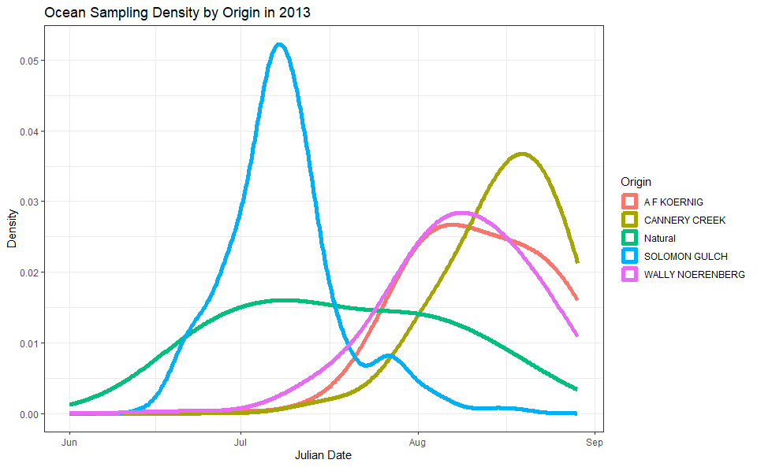

```r
ocean |>
  dplyr::mutate(date = as.Date(haul_date, format = "%m/%d/%Y"),
                julian = lubridate::yday(date),
                origin = dplyr::case_when(is.na(mark_present) ~ NA_character_,
                                          mark_present == "N" ~ "Natural",
                                          mark_present == "Y" ~ hatchery)) |>
  dplyr::filter(!is.na(origin)) |>
  ggplot2::ggplot(ggplot2::aes(x = date, colour = origin)) +
  ggplot2::geom_density(lwd = 2, adjust = 2) +
  ggplot2::theme_bw() +
  ggplot2::labs(title = "Ocean Sampling Density by Origin in 2013",
                x = "Julian Date",
                y = "Density",
                colour = "Origin")
```

Compare to the join data.

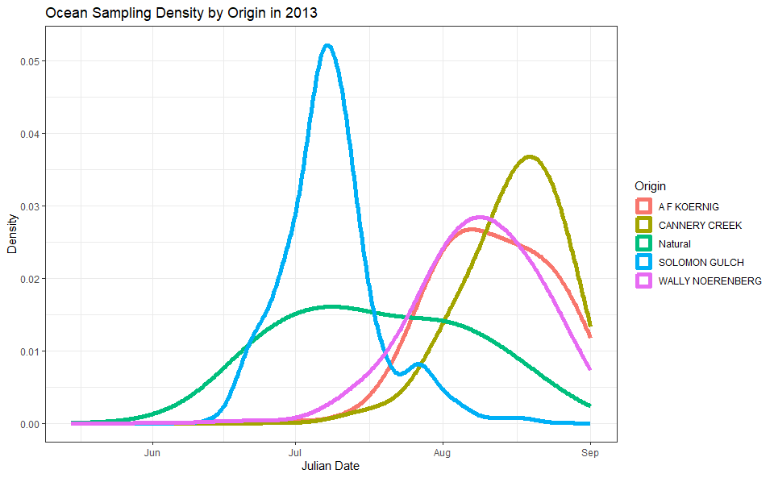

```r
ocean_join |>
  dplyr::filter(!is.na(origin),
                year_join == 2013) |>
  ggplot2::ggplot(ggplot2::aes(x = date, colour = origin)) +
  ggplot2::geom_density(lwd = 2, adjust = 2) +
  ggplot2::xlim(lubridate::as_date(c("2013-05-15", "2013-09-01"))) +
  ggplot2::theme_bw() +
  ggplot2::labs(title = "Ocean Sampling Density by Origin in 2013",
                x = "Julian Date",
                y = "Density",
                colour = "Origin")
```

It’s identical. Now 2014.

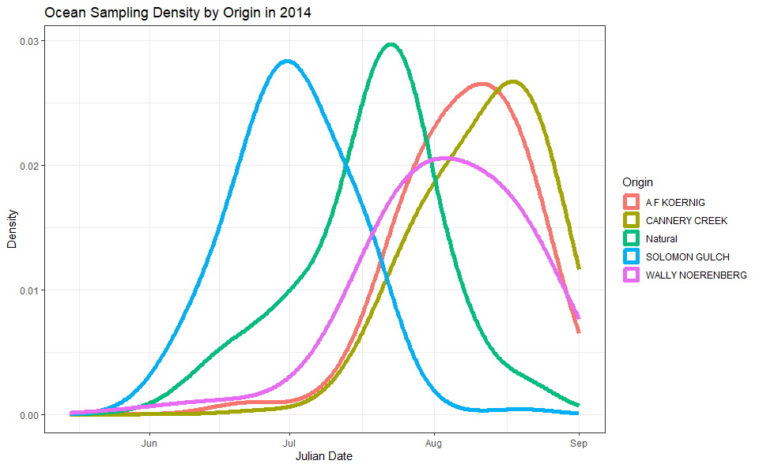

```r
ocean_join |>
  dplyr::filter(!is.na(origin),
                year_join == 2014) |>
  ggplot2::ggplot(ggplot2::aes(x = date, colour = origin)) +
  ggplot2::geom_density(lwd = 2, adjust = 2) +
  ggplot2::xlim(lubridate::as_date(c("2014-05-15", "2014-09-01"))) +
  ggplot2::theme_bw() +
  ggplot2::labs(title = "Ocean Sampling Density by Origin in 2014",
                x = "Julian Date",
                y = "Density",
                colour = "Origin")
```

Now 2015.

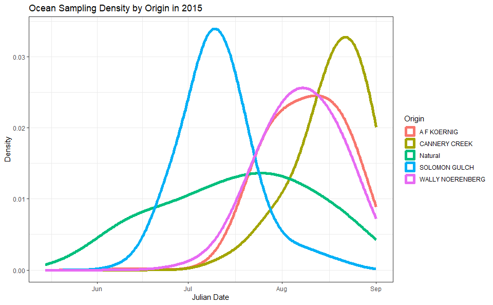

```r
ocean_join |>
  dplyr::filter(!is.na(origin),
                year_join == 2015) |>
  ggplot2::ggplot(ggplot2::aes(x = date, colour = origin)) +
  ggplot2::geom_density(lwd = 2, adjust = 2) +
  ggplot2::xlim(lubridate::as_date(c("2015-05-15", "2015-09-01"))) +
  ggplot2::theme_bw() +
  ggplot2::labs(title = "Ocean Sampling Density by Origin in 2015",
                x = "Julian Date",
                y = "Density",
                colour = "Origin")
```

#### CPUE

Get daily, average pink salmon CPUE to scale proportions

```r
CPUE_mod <- CPUE |>
  dplyr::mutate(date = lubridate::as_date(date, format = "%m/%d/%y")) |>
  dplyr::distinct(date, avg_pink_cpue)
```

Get daily proportions by origin, and multiply by CPUE.

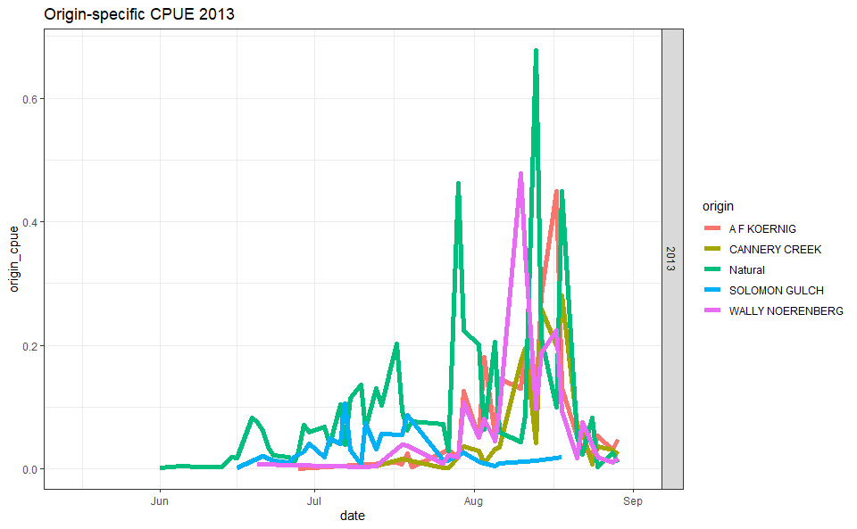

```r
ocean_join |>
  dplyr::filter(!is.na(origin),
                year_join == 2013) |>
  dplyr::count(year_join, date, origin) |>
  dplyr::group_by(year_join, date) |>
  dplyr::mutate(p = n / sum(n)) |>
  dplyr::ungroup() |>
  dplyr::left_join(y = CPUE_mod, by = dplyr::join_by(date)) |>
  dplyr::mutate(origin_cpue = p * avg_pink_cpue) |>
  ggplot2::ggplot(ggplot2::aes(x = date, y = origin_cpue, colour = origin)) +
  ggplot2::geom_line(lwd = 2) +
  ggplot2::xlim(lubridate::as_date(c("2013-05-15", "2013-09-01"))) +
  ggplot2::theme_bw() +
  ggplot2::labs(title = "Origin-specific CPUE 2013") +
  ggplot2::facet_grid(year_join ~ .)
```

While this is correct, it is gross. We want a *smoother* curve.

Get daily proportions by origin, and multiply by CPUE. Each curve integrates to 1, **does not** show the relative abundance, but rather the run timing for each group.

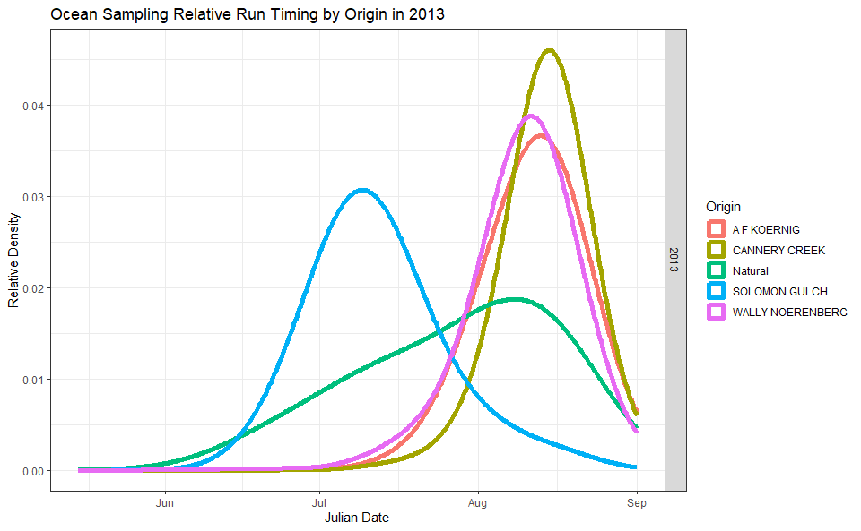

```r
ocean_join |>
  dplyr::filter(!is.na(origin),
                year_join == 2013) |>
  dplyr::count(year_join, date, origin) |>
  dplyr::group_by(year_join, date) |>
  dplyr::mutate(p = n / sum(n)) |>
  dplyr::ungroup() |>
  dplyr::left_join(y = CPUE_mod, by = dplyr::join_by(date)) |>
  dplyr::mutate(origin_cpue = p * avg_pink_cpue) |>
  ggplot2::ggplot(ggplot2::aes(x = date, colour = origin, weight = origin_cpue)) +
  ggplot2::geom_density(lwd = 2, adjust = 1) +
  ggplot2::xlim(lubridate::as_date(c("2013-05-15", "2013-09-01"))) +
  ggplot2::theme_bw() +
  ggplot2::labs(title = "Ocean Sampling Relative Run Timing by Origin in 2013",
                x = "Julian Date",
                y = "Relative Density",
                colour = "Origin") +
  ggplot2::facet_grid(year_join ~ .)
```

Get daily proportions by origin, and multiply by CPUE. Each curve **does** show the relative abundance and run timing for each group.

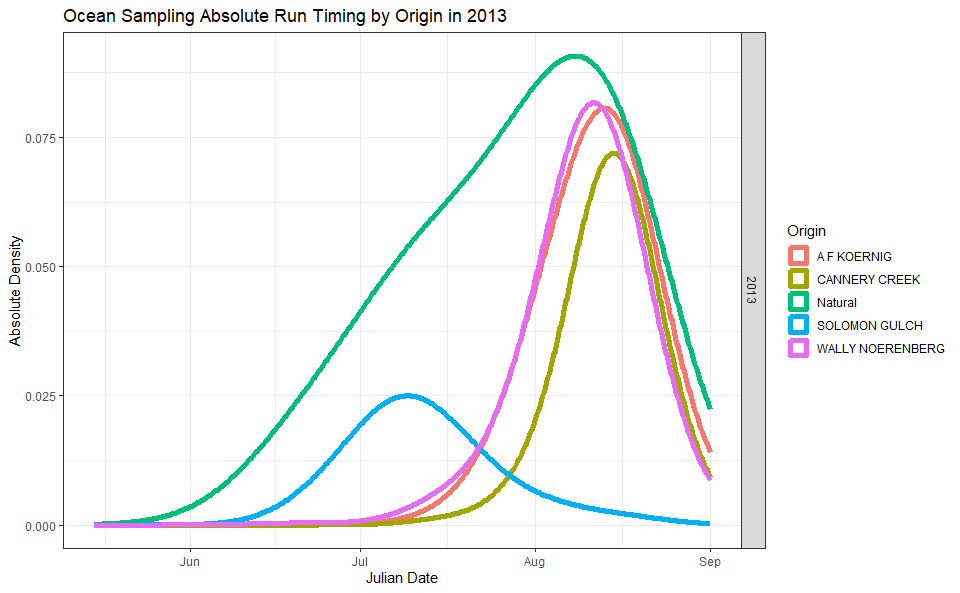

```r
ocean_join |>
  dplyr::filter(!is.na(origin),
                year_join == 2013) |>
  dplyr::count(year_join, date, origin) |>
  dplyr::group_by(year_join, date) |>
  dplyr::mutate(p = n / sum(n)) |>
  dplyr::ungroup() |>
  dplyr::left_join(y = CPUE_mod, by = dplyr::join_by(date)) |>
  dplyr::mutate(origin_cpue = p * avg_pink_cpue) |>
  ggplot2::ggplot(ggplot2::aes(x = date, colour = origin, weight = origin_cpue)) +
  ggplot2::geom_density(ggplot2::aes(y = ggplot2::after_stat(wdensity)),
                        lwd = 2, adjust = 1) +
  ggplot2::xlim(lubridate::as_date(c("2013-05-15", "2013-09-01"))) +
  ggplot2::theme_bw() +
  ggplot2::labs(title = "Ocean Sampling Absolute Run Timing by Origin in 2013",
                x = "Julian Date",
                y = "Absolute Density",
                colour = "Origin") +
  ggplot2::facet_grid(year_join ~ .)
```

```r
ggplot2::ggsave(filename = "../output/ocean_test_fishery_run_timing_2013.png", width = 10, height = 6, units = "in")
```

Get daily proportions by origin, and multiply by CPUE. Each curve **does** show the relative abundance and run timing for each group.

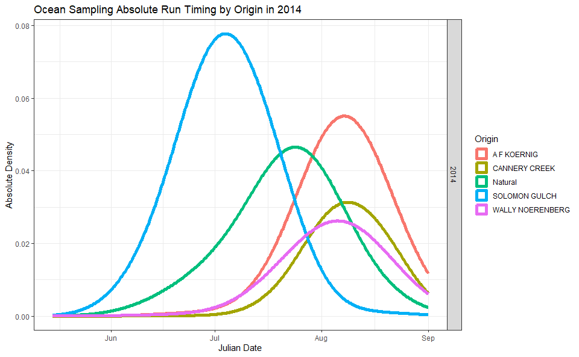

```r
ocean_join |>
  dplyr::filter(!is.na(origin),
                year_join == 2014) |>
  dplyr::count(year_join, date, origin) |>
  dplyr::group_by(year_join, date) |>
  dplyr::mutate(p = n / sum(n)) |>
  dplyr::ungroup() |>
  dplyr::left_join(y = CPUE_mod, by = dplyr::join_by(date)) |>
  dplyr::mutate(origin_cpue = p * avg_pink_cpue) |>
  ggplot2::ggplot(ggplot2::aes(x = date, colour = origin, weight = origin_cpue)) +
  ggplot2::geom_density(ggplot2::aes(y = ggplot2::after_stat(wdensity)),
                        lwd = 2, adjust = 1) +
  ggplot2::xlim(lubridate::as_date(c("2014-05-15", "2014-09-01"))) +
  ggplot2::theme_bw() +
  ggplot2::labs(title = "Ocean Sampling Absolute Run Timing by Origin in 2014",
                x = "Julian Date",
                y = "Absolute Density",
                colour = "Origin") +
  ggplot2::facet_grid(year_join ~ .)
```

```r
ggplot2::ggsave(filename = "../output/ocean_test_fishery_run_timing_2014.png", width = 10, height = 6, units = "in")
```

Get daily proportions by origin, and multiply by CPUE. Each curve **does** show the relative abundance and run timing for each group.

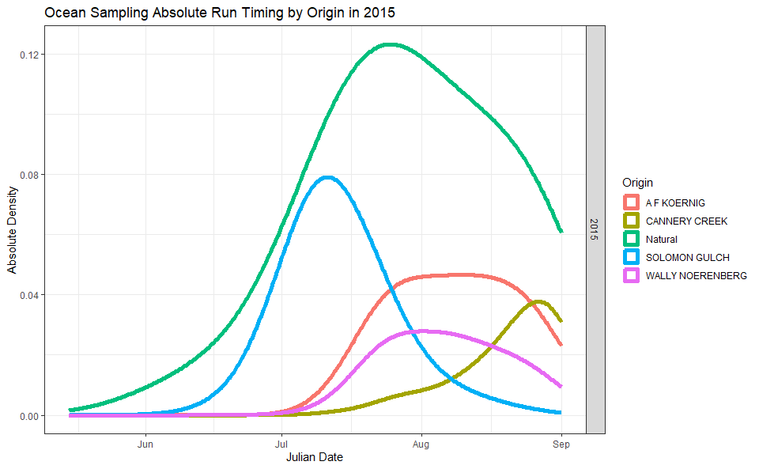

```r
ocean_join |>
  dplyr::filter(!is.na(origin),
                year_join == 2015) |>
  dplyr::count(year_join, date, origin) |>
  dplyr::group_by(year_join, date) |>
  dplyr::mutate(p = n / sum(n)) |>
  dplyr::ungroup() |>
  dplyr::left_join(y = CPUE_mod, by = dplyr::join_by(date)) |>
  dplyr::mutate(origin_cpue = p * avg_pink_cpue) |>
  ggplot2::ggplot(ggplot2::aes(x = date, colour = origin, weight = origin_cpue)) +
  ggplot2::geom_density(ggplot2::aes(y = ggplot2::after_stat(wdensity)),
                        lwd = 2, adjust = 1) +
  ggplot2::xlim(lubridate::as_date(c("2015-05-15", "2015-09-01"))) +
  ggplot2::theme_bw() +
  ggplot2::labs(title = "Ocean Sampling Absolute Run Timing by Origin in 2015",
                x = "Julian Date",
                y = "Absolute Density",
                colour = "Origin") +
  ggplot2::facet_grid(year_join ~ .)
```

```r
ggplot2::ggsave(filename = "../output/ocean_test_fishery_run_timing_2015.png", width = 10, height = 6, units = "in")
```

### Save Data

Need to save the 2014-2015 otolith data so Eric Lardizabal can upate the HWI Ocean Report [website](https://mtalab.adfg.alaska.gov/Hatchery_Wild_Interaction/HWIReports.aspx). I am choosing to overwrite the existing 2013 data, but there were only those few discrepancies.

```r
ocean_save <- ocean_join |>
  dplyr::select(-c(mark_id, mark_present, hatchery)) |>  # remove the original columns since they only have 2013 data
  dplyr::rename(mark_id = mark_id_join,
                mark_present = mark_present_join,
                hatchery = hatchery_join) |>  # rename the join columns with otolith data for all 3 years, 2013-2015
  dplyr::select(names(ocean))  # get the columns in the correct order
```

Confirm that otolith data is there for all years.

```r
ocean_save |>
  dplyr::count(year, mark_present)
```

| year | mark_present | n |
| --- | --- | --- |
| 2013 | N | 735 |
| 2013 | Y | 747 |
| 2013 | NA | 72 |
| 2014 | N | 334 |
| 2014 | Y | 1263 |
| 2014 | NA | 18 |
| 2015 | N | 1324 |
| 2015 | Y | 929 |
| 2015 | NA | 27 |

## Aerial

### Join 2024-2026 Data

Join in the raw data from 2024-2026 to the existing 1962-2023 data.

```r
# glimpse(aerial)
# glimpse(aerial_2024_2026)

# just keep the pink salmon stream counts, that's all we need for escapement
aerial_mod <- aerial |>
  dplyr::rename(
    survey_date = date,
    subdistrict = stat_area,
    stream_num = strnum,
    stream_name = strname
  ) |>
  dplyr::mutate(
    observer = paste(first, last_2),
    species = "Pink",
    count_type = "Stream",
    count = pstream
  ) |>
  dplyr::select(
    year,
    lineage,
    survey_date,
    stat_week,
    julian_day,
    district,
    subdistrict,
    stream_num,
    stream_name,
    observer,
    species,
    count_type,
    count
  )

aerial_2024_2026_mod <- aerial_2024_2026 |>
  dplyr::mutate(year = lubridate::year(survey_date),
                lineage = dplyr::case_when(year %% 2 == 0 ~ "Even",
                                 year %% 2 == 1 ~ "Odd",
                                 TRUE ~ NA_character_),
                julian_day = lubridate::yday(survey_date),
                subdistrict = as.numeric(stringr::str_sub(string = stat_area, start = -2, end = -1)),
                stream_num = stream
                ) |>
  dplyr::filter(species == "Pink",
                count_type == "Stream") |>
  dplyr::select(
    year,
    lineage,
    survey_date,
    stat_week,
    julian_day,
    district,
    subdistrict,
    stream_num,
    stream_name,
    observer,
    species,
    count_type,
    count
  )

(
  aerial_1962_2026 <- dplyr::bind_rows(aerial_mod, aerial_2024_2026_mod) |>
    dplyr::arrange(year, district, subdistrict, stream_num, survey_date)
)
```

| year | lineage | survey_date | stat_week | julian_day | district | subdistrict | stream_num | stream_name | observer | species | count_type | count |
| --- | --- | --- | --- | --- | --- | --- | --- | --- | --- | --- | --- | --- |
| 1963 | Odd | 1963-08-23 | 34 | 235 | 221 | 10 | 1 | Hartney Bay South | Wally Noerenberg | Pink | Stream | 200 |
| 1963 | Odd | 1963-06-29 | 26 | 180 | 221 | 10 | 2 | Hartney Creek | Wally Noerenberg | Pink | Stream | 0 |
| 1963 | Odd | 1963-07-19 | 29 | 200 | 221 | 10 | 2 | Hartney Creek | Ralph Pirtle | Pink | Stream | 50 |
| 1963 | Odd | 1963-07-27 | 30 | 208 | 221 | 10 | 2 | Hartney Creek | Ralph Pirtle | Pink | Stream | 50 |
| 1963 | Odd | 1963-08-23 | 34 | 235 | 221 | 10 | 2 | Hartney Creek | Wally Noerenberg | Pink | Stream | 2300 |
| 1963 | Odd | 1963-08-23 | 34 | 235 | 221 | 10 | 3 | Nicolet Creek | Wally Noerenberg | Pink | Stream | 50 |
| 1963 | Odd | 1963-08-23 | 34 | 235 | 221 | 10 | 4 | Heney Creek | Wally Noerenberg | Pink | Stream | 200 |
| 1963 | Odd | 1963-06-29 | 26 | 180 | 221 | 10 | 5 | Eccles Creek | Wally Noerenberg | Pink | Stream | 0 |
| 1963 | Odd | 1963-08-23 | 34 | 235 | 221 | 10 | 5 | Eccles Creek | Wally Noerenberg | Pink | Stream | 200 |
| 1963 | Odd | 1963-06-17 | 25 | 168 | 221 | 10 | 8 | Fleming Creek | Wally Noerenberg | Pink | Stream | 0 |

[output cut: 990 more lines]

```r
rm(aerial, aerial_2024_2026, aerial_mod, aerial_2024_2026_mod)
```

### 134 Index Streams

The aerial survey program was reduced to 134 index streams starting in 2015. For a true apples-to-apples comparison, I’m going to limit the historical data to these 134 streams as well. They are listed in Appendix A1 of [Morella and Scannell 2024](https://www.adfg.alaska.gov/FedAidPDFs/ROP.CF.2A.2024.04.pdf), but it doesn’t include the stream number. I’m going to see if I can figure it out based on which streams were surveyed in recent years.

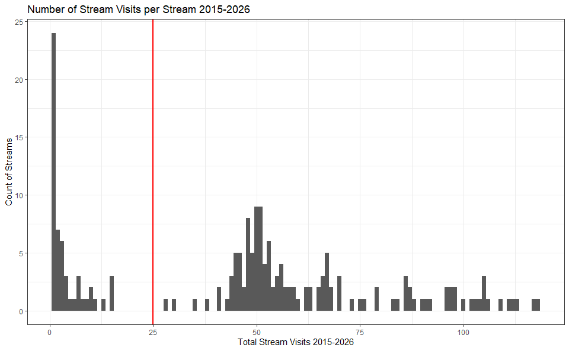

```r
aerial_1962_2026 |>
  dplyr::filter(year >= 2015) |>  # just the reduced set of 134 index streams
  dplyr::count(district, subdistrict, stream_num, stream_name) |>
  ggplot2::ggplot(ggplot2::aes(x = n)) +
  ggplot2::geom_histogram(binwidth = 1) +
  ggplot2::geom_vline(xintercept = 25, colour = "red", lwd = 1) +
  ggplot2::theme_bw() +
  ggplot2::labs(x = "Total Stream Visits 2015-2026", y = "Count of Streams", title = "Number of Stream Visits per Stream 2015-2026")
```

It looks like 25 might be a reasonable cutoff, how many total streams will that leave us with?

```r
aerial_1962_2026 |>
  dplyr::filter(year >= 2015) |>  # just the reduced set of 134 index streams
  dplyr::count(district, subdistrict, stream_num, stream_name) |>
  dplyr::filter(n > 25) |>
  dplyr::arrange(district, subdistrict, stream_num)
```

| district | subdistrict | stream_num | stream_name | n |
| --- | --- | --- | --- | --- |
| 221 | 10 | 2 | Hartney Creek | 57 |
| 221 | 10 | 11 | Humpy Creek | 103 |
| 221 | 20 | 20 | Spring Creek | 113 |
| 221 | 20 | 23 | Chase Creek | 104 |
| 221 | 20 | 35 | Koppen Creek | 118 |
| 221 | 20 | 36 | Sheep Creek | 106 |
| 221 | 30 | 46 | Comfort Creek | 109 |
| 221 | 30 | 48 | Beartrap River | 117 |
| 221 | 30 | 51 | Olsen Creek | 112 |
| 221 | 30 | 52 | Control Creek | 111 |

[output cut: 124 more lines]

Perfect, this gives us exactly 134 streams. Hopefully, these are the correct index streams!

How many total surveys per year? Curious if there were notably fewer in 1964, 1989, or 1990.

```r
aerial_1962_2026 |>
  dplyr::count(year) |>
  dplyr::arrange(n)
```

| year | n |
| --- | --- |
| 1968 | 455 |
| 2022 | 507 |
| 2023 | 522 |
| 1974 | 536 |
| 2016 | 552 |
| 2024 | 574 |
| 1966 | 639 |
| 1970 | 654 |
| 2021 | 715 |
| 1969 | 739 |

[output cut: 54 more lines]

Quick-n-dirty, assume the streams w/ >25 visits are correct.

```r
# get 134 index streams
index_streams <- aerial_1962_2026 |>
  dplyr::filter(year >= 2015) |>  # just the reduced set of 134 index streams
  dplyr::count(district, subdistrict, stream_num, stream_name) |>
  dplyr::filter(n > 25) |>
  dplyr::select(district, subdistrict, stream_num, stream_name)
```

### Annual x District

Get total annual escapement by district.

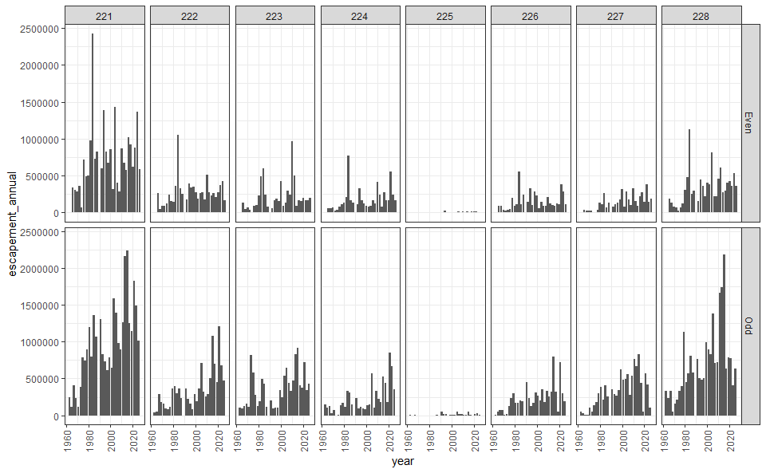

```r
# annual cumulative escapement by district
annual_district <- aerial_1962_2026 |>
  dplyr::filter(stream_num %in% index_streams$stream_num,  # only index streams
                !year %in% c(1964, 1989, 1990),  # drop years for earthquake, Exxon Valdez
                count_type == "Stream",  # only stream counts are escapement
                species == "Pink",
                district %in% 221:228  # ditch Unakwik (229)
                ) |>
  dplyr::group_by(lineage, year, district) |>
  dplyr::summarise(escapement_annual = sum(count, na.rm = TRUE), .groups = "drop")

# plot
annual_district |>
  ggplot2::ggplot(ggplot2::aes(x = year, y = escapement_annual)) +
  ggplot2::geom_col() +
  ggplot2::theme_bw() +
  ggplot2::theme(axis.text.x = ggplot2::element_text(angle = 90, vjust = 0.5, hjust = 1)) +
  ggplot2::facet_grid(lineage ~ district)
```

### Daily x District

Get daily cumulative escapement by district, fill in unsurveyed days from first to last day surveyed across full dataset. Then calculate the daily proportion of escapement by district and cumulative proportion of escapement by district for each year.

```r
# daily cumulative escapement by district
daily_district <- aerial_1962_2026 |>
  dplyr::filter(stream_num %in% index_streams$stream_num,  # only index streams
                !year %in% c(1964, 1989, 1990),  # drop years for earthquake, Exxon Valdez
                count_type == "Stream",  # only stream counts are escapement
                species == "Pink",
                district %in% 221:228  # ditch Unakwik (229)
                ) |>
  dplyr::group_by(lineage, year, district, julian_day) |>
  dplyr::summarise(escapement_daily = sum(count, na.rm = TRUE), .groups = "drop_last") |>
  tidyr::complete(julian_day = seq(min(aerial_1962_2026$julian_day), max(aerial_1962_2026$julian_day)),  # fill in unsurveyed days w/ 0
                  fill = list(escapement_daily = 0)) |>
  dplyr::arrange(julian_day, .by_group = TRUE) |>
  dplyr::mutate(escapement_cumulative = cumsum(escapement_daily)) |>
  dplyr::ungroup() |>
  dplyr::left_join(y = annual_district, by = dplyr::join_by(lineage, year, district)) |>
  dplyr::mutate(p_daily = escapement_daily / escapement_annual,
                p_cumulative = escapement_cumulative / escapement_annual)
```

Check to make sure working as intended.

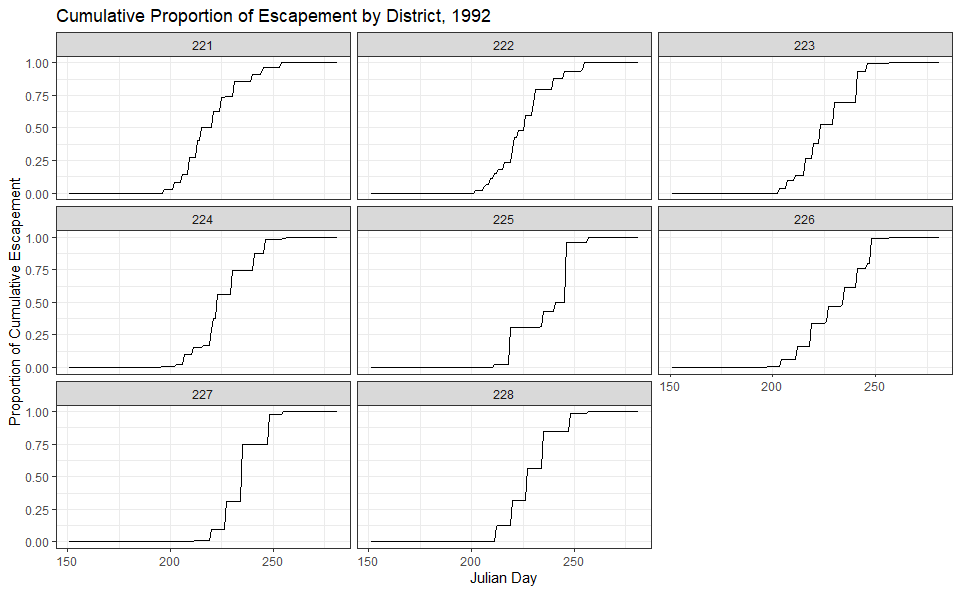

```r
# Cumulative
daily_district |>
  dplyr::filter(year == 1992) |>
  ggplot2::ggplot(ggplot2::aes(x = julian_day, y = p_cumulative)) +
  ggplot2::geom_line() +
  ggplot2::theme_bw() +
  ggplot2::facet_wrap(~ district) +
  ggplot2::labs(x = "Julian Day", y = "Proportion of Cumulative Escapement", title = "Cumulative Proportion of Escapement by District, 1992")
```

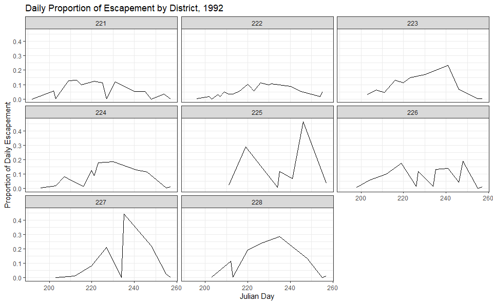

```r
# Daily
daily_district |>
  dplyr::filter(year == 1992,
                p_daily > 0) |>
  ggplot2::ggplot(ggplot2::aes(x = julian_day, y = p_daily)) +
  ggplot2::geom_line() +
  ggplot2::theme_bw() +
  ggplot2::facet_wrap(~ district) +
  ggplot2::labs(x = "Julian Day", y = "Proportion of Daily Escapement", title = "Daily Proportion of Escapement by District, 1992")
```

### Average Timing

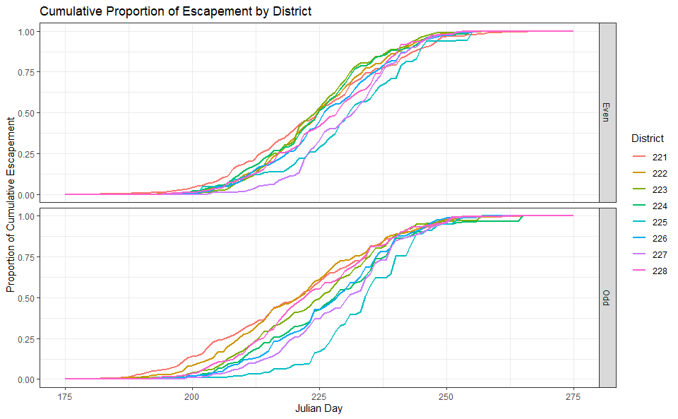

```r
mean_district <- daily_district |>
  dplyr::filter(escapement_annual > 0) |>
  dplyr::group_by(lineage, district, julian_day) |>
  dplyr::summarise(p_daily = mean(p_daily),
                   p_cumulative = mean(p_cumulative),
                   n_years = dplyr::n_distinct(year),
                   .groups = "drop")

# Cumulative
mean_district |>
  dplyr::mutate(district = as.character(district)) |>
  ggplot2::ggplot(ggplot2::aes(x = julian_day, y = p_cumulative, colour = district)) +
  ggplot2::geom_line(lwd = 1) +
  ggplot2::xlim(c(175, 275)) +
  ggplot2::theme_bw() +
  ggplot2::facet_grid(lineage ~ .) +
  ggplot2::labs(
    x = "Julian Day",
    y = "Proportion of Cumulative Escapement",
    title = "Cumulative Proportion of Escapement by District",
    colour = "District"
  )
```

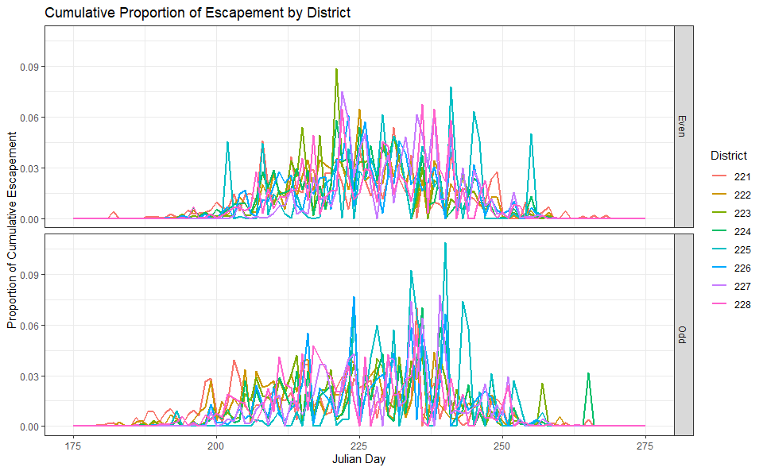

```r
# Daily
mean_district |>
  dplyr::mutate(district = as.character(district)) |>
  ggplot2::ggplot(ggplot2::aes(x = julian_day, y = p_daily, colour = district)) +
  ggplot2::geom_line(lwd = 1) +
  ggplot2::xlim(c(175, 275)) +
  ggplot2::theme_bw() +
  ggplot2::facet_grid(lineage ~ .) +
  ggplot2::labs(
    x = "Julian Day",
    y = "Proportion of Cumulative Escapement",
    title = "Cumulative Proportion of Escapement by District",
    colour = "District"
  )
```

Try smoothing.

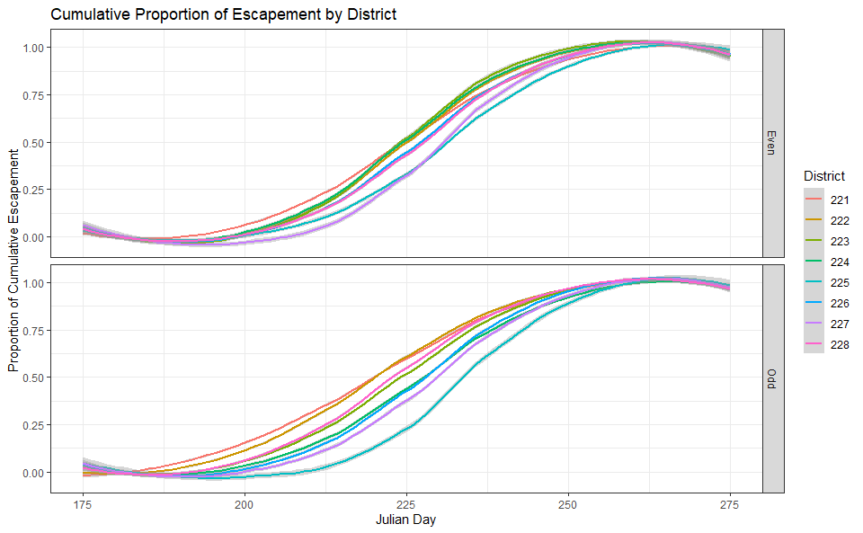

```r
# Cumulative
mean_district |>
  dplyr::mutate(district = as.character(district)) |>
  ggplot2::ggplot(ggplot2::aes(x = julian_day, y = p_cumulative, colour = district)) +
  ggplot2::geom_smooth(lwd = 1) +
  ggplot2::xlim(c(175, 275)) +
  ggplot2::theme_bw() +
  ggplot2::facet_grid(lineage ~ .) +
  ggplot2::labs(
    x = "Julian Day",
    y = "Proportion of Cumulative Escapement",
    title = "Cumulative Proportion of Escapement by District",
    colour = "District"
  )
```

Try a 14-day moving average.

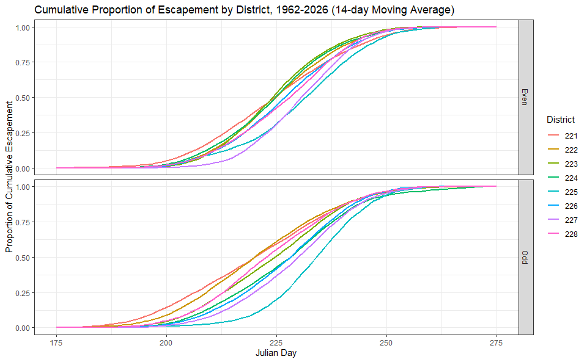

```r
mean_district %>%
  dplyr::group_by(lineage, district) %>%
  dplyr::arrange(julian_day, .by_group = TRUE) %>%
  dplyr::mutate(
    p_cumulative_smoothed = slider::slide_dbl(
      p_cumulative,
      mean,
      .before = 7,
      .after = 7,
      .complete = FALSE
    )
  ) %>%
  dplyr::ungroup() |>
  dplyr::mutate(district = as.character(district)) |>
  ggplot2::ggplot(ggplot2::aes(x = julian_day, y = p_cumulative_smoothed, colour = district)) +
  ggplot2::geom_line(lwd = 1) +
  ggplot2::xlim(c(175, 275)) +
  ggplot2::theme_bw() +
  ggplot2::facet_grid(lineage ~ .) +
  ggplot2::labs(
    x = "Julian Day",
    y = "Proportion of Cumulative Escapement",
    title = "Cumulative Proportion of Escapement by District, 1962-2026 (14-day Moving Average)",
    colour = "District"
  )
```

```r
ggplot2::ggsave(filename = "../output/escapement_run_timing_by_district.png", width = 10, height = 6, units = "in")
```

### Sound-wide

Get total annual escapement for all of PWS.

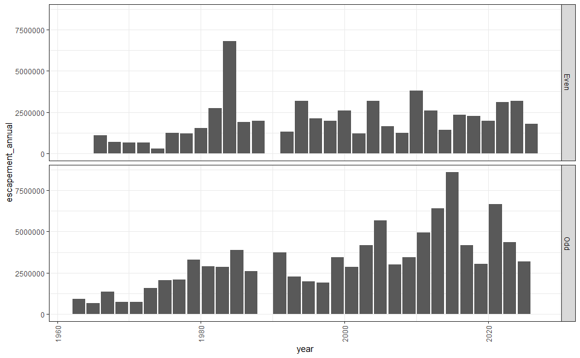

```r
# annual cumulative escapement by district
annual_pws <- aerial_1962_2026 |>
  dplyr::filter(stream_num %in% index_streams$stream_num,  # only index streams
                !year %in% c(1964, 1989, 1990),  # drop years for earthquake, Exxon Valdez
                count_type == "Stream",  # only stream counts are escapement
                species == "Pink",
                district %in% 221:228  # ditch Unakwik (229)
                ) |>
  dplyr::group_by(lineage, year) |>
  dplyr::summarise(escapement_annual = sum(count, na.rm = TRUE), .groups = "drop")

# plot
annual_pws |>
  ggplot2::ggplot(ggplot2::aes(x = year, y = escapement_annual)) +
  ggplot2::geom_col() +
  ggplot2::theme_bw() +
  ggplot2::theme(axis.text.x = ggplot2::element_text(angle = 90, vjust = 0.5, hjust = 1)) +
  ggplot2::facet_grid(lineage ~ .)
```

Get daily cumulative escapement for all of PWS, fill in unsurveyed days from first to last day surveyed across full dataset. Then calculate the daily proportion of escapement and cumulative proportion of escapement for each year.

```r
# daily cumulative escapement for all of PWS
daily_pws <- aerial_1962_2026 |>
  dplyr::filter(stream_num %in% index_streams$stream_num,  # only index streams
                !year %in% c(1964, 1989, 1990),  # drop years for earthquake, Exxon Valdez
                count_type == "Stream",  # only stream counts are escapement
                species == "Pink",
                district %in% 221:228  # ditch Unakwik (229)
                ) |>
  dplyr::group_by(lineage, year, julian_day) |>
  dplyr::summarise(escapement_daily = sum(count, na.rm = TRUE), .groups = "drop_last") |>
  tidyr::complete(julian_day = seq(min(aerial_1962_2026$julian_day), max(aerial_1962_2026$julian_day)),  # fill in unsurveyed days w/ 0
                  fill = list(escapement_daily = 0)) |>
  dplyr::arrange(julian_day, .by_group = TRUE) |>
  dplyr::mutate(escapement_cumulative = cumsum(escapement_daily)) |>
  dplyr::ungroup() |>
  dplyr::left_join(y = annual_pws, by = dplyr::join_by(lineage, year)) |>
  dplyr::mutate(p_daily = escapement_daily / escapement_annual,
                p_cumulative = escapement_cumulative / escapement_annual)
```

Average run timing by lineage for all PWS.

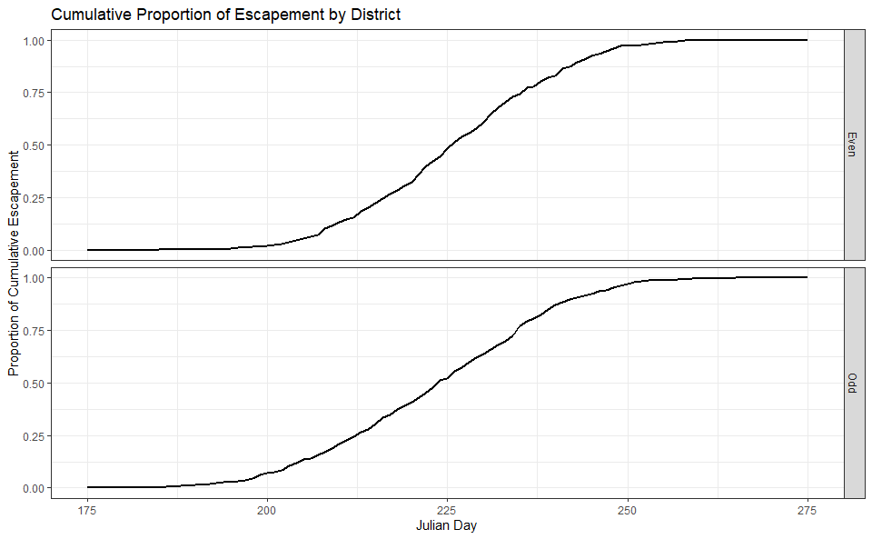

```r
mean_pws <- daily_pws |>
  dplyr::filter(escapement_annual > 0) |>
  dplyr::group_by(lineage, julian_day) |>
  dplyr::summarise(p_daily = mean(p_daily),
                   p_cumulative = mean(p_cumulative),
                   n_years = dplyr::n_distinct(year),
                   .groups = "drop")

# Cumulative
mean_pws |>
  ggplot2::ggplot(ggplot2::aes(x = julian_day, y = p_cumulative)) +
  ggplot2::geom_line(lwd = 1) +
  ggplot2::xlim(c(175, 275)) +
  ggplot2::theme_bw() +
  ggplot2::facet_grid(lineage ~ .) +
  ggplot2::labs(
    x = "Julian Day",
    y = "Proportion of Cumulative Escapement",
    title = "Cumulative Proportion of Escapement by District"
  )
```

Try a 14-day moving average.

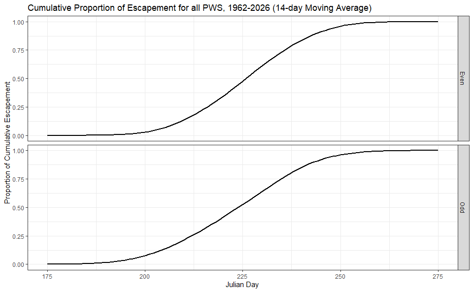

```r
mean_pws %>%
  dplyr::group_by(lineage) %>%
  dplyr::arrange(julian_day, .by_group = TRUE) %>%
  dplyr::mutate(
    p_cumulative_smoothed = slider::slide_dbl(
      p_cumulative,
      mean,
      .before = 7,
      .after = 7,
      .complete = FALSE
    )
  ) %>%
  dplyr::ungroup() |>
  ggplot2::ggplot(ggplot2::aes(x = julian_day, y = p_cumulative_smoothed)) +
  ggplot2::geom_line(lwd = 1) +
  ggplot2::xlim(c(175, 275)) +
  ggplot2::theme_bw() +
  ggplot2::facet_grid(lineage ~ .) +
  ggplot2::labs(
    x = "Julian Day",
    y = "Proportion of Cumulative Escapement",
    title = "Cumulative Proportion of Escapement for all PWS, 1962-2026 (14-day Moving Average)"
  )
```

```r
ggplot2::ggsave(filename = "../output/escapement_run_timing_all_pws.png", width = 10, height = 6, units = "in")
```

### Save Data

```r
# district data w/ smoothing
mean_district %>%
  dplyr::group_by(lineage, district) %>%
  dplyr::arrange(julian_day, .by_group = TRUE) %>%
  dplyr::mutate(
    p_cumulative_smoothed = slider::slide_dbl(
      p_cumulative,
      mean,
      .before = 7,
      .after = 7,
      .complete = FALSE
    )
  ) %>%
  dplyr::ungroup() |>
  readr::write_csv(file = "../output/escapement_run_timing_by_district.csv")

# pws data w/ smoothing
mean_pws %>%
  dplyr::group_by(lineage) %>%
  dplyr::arrange(julian_day, .by_group = TRUE) %>%
  dplyr::mutate(
    p_cumulative_smoothed = slider::slide_dbl(
      p_cumulative,
      mean,
      .before = 7,
      .after = 7,
      .complete = FALSE
    )
  ) %>%
  dplyr::ungroup() |>
  readr::write_csv(file = "../output/escapement_run_timing_all_pws.csv")
```

End